# Waste Management, Inc. (NYSE: WM) — Proyecto Final

Derivados | Emisión de bono convertible con call spread (caso Molson Coors aplicado a WM)

Productos derivados y administración de riesgos corporativos (Gpo 40) · Profesor: Dr. Raymundo Díaz Robles

Tania Manuela López Suárez (A00819037) · Mauricio Martínez García (A00826170) · Ricardo Terrazas Duque (A01566884)

Datos LSEG Workspace al 21-oct-2026 · Reporte generado 07/11/2026

# Resumen ejecutivo

Cupón del convertible a la par  
**2.41%**  
vs. 5.65% del bono directo WM a 6 años

Precio de conversión  
**$286.98**  
prima de 25% · 3.4846 acciones/bono

Costo neto del call spread  
**$54.4 mm**  
7.3% del principal · prima efectiva 60%

Ahorro anual de cupones  
**$26.2 mm**  
$20.7 mm después de impuestos

**Situación problema.** WM tiene tres bonos con cupones altos (7.00%, 7.75% y 6.125%) emitidos cuando las tasas eran mayores. Siguiendo el caso *Molson Coors*, evaluamos emitir **USD 750 mm en un bono convertible a 6 años**, recomprar esos bonos y comprar un **call spread** (note hedge al 25% + warrants vendidos al 60%) para que la dilución solo ocurra si la acción supera **$367.33**.

**Resultado.** Valuado en un árbol binomial con conversión anticipada, dividendos y riesgo de crédito (Tsiveriotis-Fernandes), el convertible queda a la par con un cupón de **2.41%**, 324 pb por debajo de la deuda directa. Los recursos alcanzan para la recompra ($679.4 mm), la comisión y el call spread ($54.4 mm), y sobran $1.3 mm.

**Fechas de los datos:** los insumos de LSEG son del 21-oct-2026 y los pares del 28-oct-2026. Las capturas del Anexo A se tomaron el 03-nov-2026, por eso algunos valores de las pantallas difieren de los del análisis (precio, curva del emisor, LTM al 30-sep-26). Los precios diarios para GARCH (Yahoo Finance) llegan al 03-nov-2026.

**Recomendación:** emitir, pero con dos condiciones, una sobre la prima de conversión y otra sobre el tamaño del call spread (ver Recomendación).

# 1. Situación problema y propuesta de estrategia

**Caso base:** *Molson Coors Brewing Co.: Valuing a Convertible Bond* (Deutsche Bank, 2007). Molson emitió un convertible a 6 años (cupón 2.5%, prima 25%) y lo combinó con un **call spread** (compra de calls al 25% y venta de warrants al 60%) para elevar la prima efectiva; usó los recursos para **recomprar deuda cara** (bono 6.375% 2012).

**Propuesta para WM (hipotética):**

- Emitir **USD 750 mm** en bonos convertibles senior a **6 años** con prima de conversión de **25%**.
- Usar los recursos para recomprar sus 3 bonos de cupón más alto: **7.00% 2028, 7.75% 2032 y 6.125% 2039** (USD 647 mm nominales).
- Comprar un *note hedge* (calls al 25%) y vender *warrants* al 60% → **prima efectiva de 60%**.
- Preguntas a resolver: ¿qué cupón deja el convertible a la par? ¿cuánto cuesta el call spread? ¿le conviene a WM?

**Por qué WM y su relación con nuestro portafolio.** El portafolio especulativo del equipo en Investopedia (Portafolio Final) está en AAPL, JPM, NVDA, TSLA y XOM: tecnología, banca, autos y energía, con betas altas. Para el proyecto de cobertura elegimos una empresa nueva de un sector que no tenemos y con el perfil opuesto: **WM es defensiva** (beta de 5 años de 0.41, frente a NVDA y TSLA, con betas muy por encima de 1), con flujos recurrentes por contratos de recolección y calificación **A-**. Cumple todas las reglas del proyecto: cotiza en NYSE y presenta 10-K, 10-Q y 8-K; tiene USD 17.9 mil mm en bonos y reporta derivados en sus notas (Nota 2 y Nota 6); su acción tiene opciones listadas, incluidas LEAPS a 2029; y tiene necesidades reales de cobertura: bonos de cupón alto para refinanciar, USD 2.9 mil mm de deuda a tasa variable y un bono en dólares canadienses. Así, el portafolio de Investopedia es la parte **especulativa** del curso y WM es la parte **coberturista**: todas las operaciones de este reporte (call spread, T-lock, futuros y swaps) cubren un riesgo de WM.

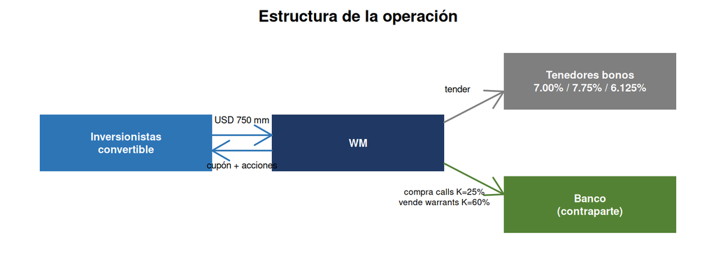

```r
par(mar = c(0, 0, 2, 0))
plot(NA, xlim = c(0, 10), ylim = c(0, 4), axes = FALSE, xlab = "", ylab = "",
     main = "Estructura de la operación")
caja <- function(x, y, txt, col) { rect(x - 1.3, y - 0.55, x + 1.3, y + 0.55, col = col, border = NA)
                                    text(x, y, txt, col = "white", cex = 0.8, font = 2) }
caja(1.5, 2, "Inversionistas\nconvertible", azul2); caja(5, 2, "WM", azul)
caja(8.5, 3.2, "Tenedores bonos\n7.00% / 7.75% / 6.125%", gris); caja(8.5, 0.8, "Banco\n(contraparte)", verde)
arrows(2.8, 2.15, 3.7, 2.15, lwd = 2, col = azul2); text(3.25, 2.45, "USD 750 mm", cex = 0.7)
arrows(3.7, 1.85, 2.8, 1.85, lwd = 2, col = azul2); text(3.25, 1.55, "cupón + acciones", cex = 0.7)
arrows(6.3, 2.4, 7.2, 3.0, lwd = 2, col = gris); text(6.5, 3.05, "tender", cex = 0.7)
arrows(6.3, 1.6, 7.2, 1.0, lwd = 2, col = verde); text(6.3, 0.95, "compra calls K=25%\nvende warrants K=60%", cex = 0.65)
```

# 2. Overview de la empresa

Precio de cierre  
**$229.58**  
21-oct-2026

Market cap  
**$91.8 bn**  
399.7 mm acciones

Enterprise value  
**$114.6 bn**  
EV/EBITDA LTM 14.6x

Calificación  
**A- / A-**  
S&P / Fitch

**Descripción (LSEG):** Waste Management, Inc. es proveedor de soluciones ambientales en EE.UU. y Canadá: recolección, reciclaje y disposición de residuos. Segmentos: *East Tier, West Tier, Recycling Processing and Sales, WM Renewable Energy* y *WM Healthcare Solutions* (residuos regulados y destrucción segura de información). Sector TRBC: *Environmental Services & Equipment*.

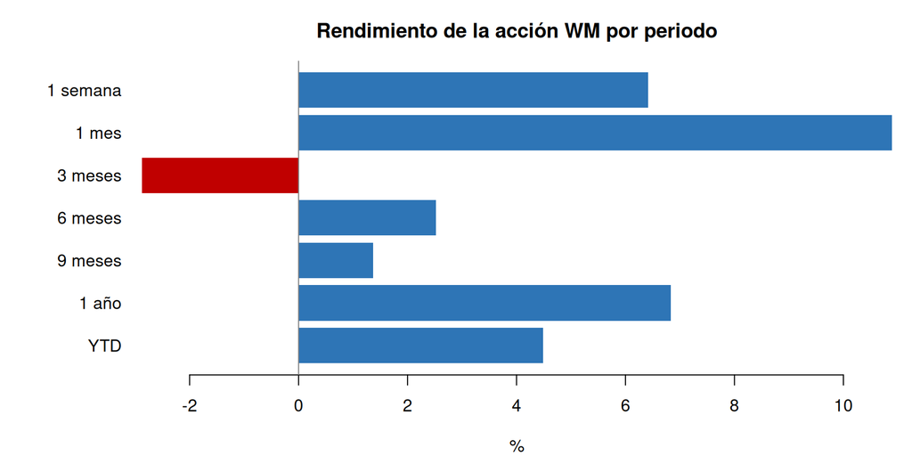

```r
desempeno <- data.frame(
  Periodo = c("1 semana", "1 mes", "3 meses", "6 meses", "9 meses", "1 año", "YTD"),
  Rendimiento = c(6.4121, 10.8868, -2.8766, 2.5231, 1.3643, 6.8361, 4.4923) / 100
)
mercado <- data.frame(
  Concepto = c("Máximo 52 semanas", "Mínimo 52 semanas", "Vol. histórica 10d", "Vol. histórica 30d",
               "Vol. histórica 90d", "Vol. histórica 200d", "Beta 2 años", "Beta 5 años",
               "Dividend yield bruto", "Precio / valor en libros", "Volumen promedio 30d"),
  Valor = c("$248.10 (06-mar-2026)", "$194.15 (03-nov-2025)", "21.74%", "19.76%", "21.04%", "20.71%",
            "-0.07", "0.41", "1.63%", "9.25x", "671,734")
)
par(mar = c(4, 7, 3, 1))
barplot(rev(desempeno$Rendimiento) * 100, names.arg = rev(desempeno$Periodo), horiz = TRUE, las = 1,
        col = ifelse(rev(desempeno$Rendimiento) >= 0, azul2, rojo), border = NA,
        xlab = "%", main = "Rendimiento de la acción WM por periodo")
abline(v = 0, col = gris)
```

```r
tabla(mercado, "Indicadores de mercado (LSEG: Price Performance)")
```

Indicadores de mercado (LSEG: Price Performance)

| Concepto | Valor |
| --- | --- |
| Máximo 52 semanas | $248.10 (06-mar-2026) |
| Mínimo 52 semanas | $194.15 (03-nov-2025) |
| Vol. histórica 10d | 21.74% |
| Vol. histórica 30d | 19.76% |
| Vol. histórica 90d | 21.04% |
| Vol. histórica 200d | 20.71% |
| Beta 2 años | -0.07 |
| Beta 5 años | 0.41 |
| Dividend yield bruto | 1.63% |
| Precio / valor en libros | 9.25x |
| Volumen promedio 30d | 671,734 |

**Lectura:** WM es una acción defensiva (beta a 5 años de 0.41) con volatilidad histórica de ~20-21%. Para la opción de conversión eso implica un valor moderado, y un cupón del convertible bajo pero no extremo.

# 3. Análisis financiero y ratios

```r
ratios <- data.frame(
  Ratio = c("EV / Revenue", "EV / EBITDA", "EV / EBIT", "Deuda total / EV", "Deuda total / EBITDA",
            "EBITDA / Intereses", "(EBITDA - Capex) / Intereses", "EBIT / Intereses", "P / U",
            "Dividend yield (%)", "FOCF yield (%)", "Precio / Ventas", "Precio / Flujo"),
  LTM_jun26 = c(4.46, 14.61, 23.72, 0.20, 2.98, 8.65, 5.09, 5.33, 32.50, 1.54, 3.89, 3.61, 14.23),
  FY2024 = c(4.74, 16.28, 25.18, 0.23, 3.73, 10.73, 5.33, 6.94, 29.64, 1.52, 2.67, 3.69, 15.10),
  FY2025 = c(4.41, 14.89, 24.14, 0.21, 3.07, 8.19, 4.65, 5.05, 32.79, 1.13, 3.18, 3.52, 14.70),
  FY2026e = c(4.34, 13.97, 22.47, NA, 2.85, 8.89, 6.01, 5.53, 28.24, 1.63, 4.14, 3.47, 14.90),
  FY2027e = c(4.12, 13.06, 20.53, NA, 2.66, 9.54, 6.43, 6.07, 25.31, 1.73, 4.53, 3.30, 13.79),
  FY2028e = c(3.94, 12.32, 19.08, NA, 2.51, 10.60, 7.21, 6.84, 23.14, 1.82, 4.85, 3.15, 12.07)
)
tabla(ratios, "Key Ratios — históricos y consenso (media) LSEG")
```

Key Ratios — históricos y consenso (media) LSEG

| Ratio | LTM_jun26 | FY2024 | FY2025 | FY2026e | FY2027e | FY2028e |
| --- | --- | --- | --- | --- | --- | --- |
| EV / Revenue | 4.46 | 4.74 | 4.41 | 4.34 | 4.12 | 3.94 |
| EV / EBITDA | 14.61 | 16.28 | 14.89 | 13.97 | 13.06 | 12.32 |
| EV / EBIT | 23.72 | 25.18 | 24.14 | 22.47 | 20.53 | 19.08 |
| Deuda total / EV | 0.20 | 0.23 | 0.21 | NA | NA | NA |
| Deuda total / EBITDA | 2.98 | 3.73 | 3.07 | 2.85 | 2.66 | 2.51 |
| EBITDA / Intereses | 8.65 | 10.73 | 8.19 | 8.89 | 9.54 | 10.60 |
| (EBITDA - Capex) / Intereses | 5.09 | 5.33 | 4.65 | 6.01 | 6.43 | 7.21 |
| EBIT / Intereses | 5.33 | 6.94 | 5.05 | 5.53 | 6.07 | 6.84 |
| P / U | 32.50 | 29.64 | 32.79 | 28.24 | 25.31 | 23.14 |
| Dividend yield (%) | 1.54 | 1.52 | 1.13 | 1.63 | 1.73 | 1.82 |
| FOCF yield (%) | 3.89 | 2.67 | 3.18 | 4.14 | 4.53 | 4.85 |
| Precio / Ventas | 3.61 | 3.69 | 3.52 | 3.47 | 3.30 | 3.15 |
| Precio / Flujo | 14.23 | 15.10 | 14.70 | 14.90 | 13.79 | 12.07 |

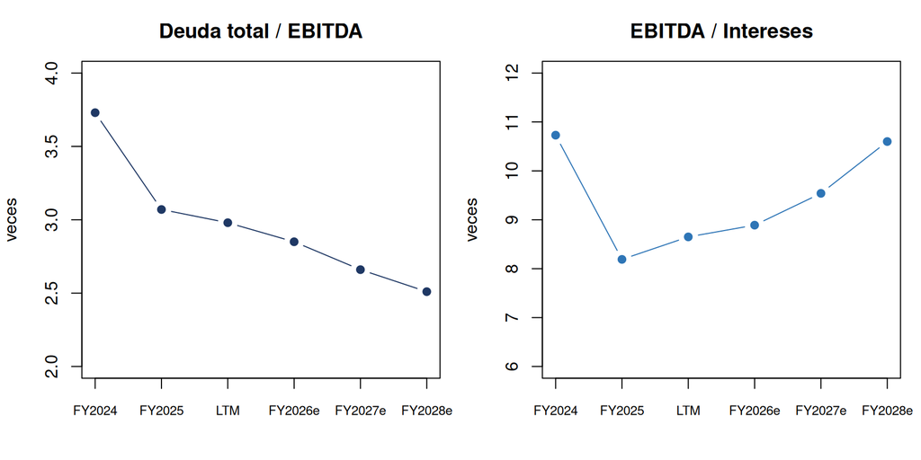

```r
anios <- c("FY2024", "FY2025", "LTM", "FY2026e", "FY2027e", "FY2028e")
apal  <- c(3.73, 3.07, 2.98, 2.85, 2.66, 2.51)
cobert <- c(10.73, 8.19, 8.65, 8.89, 9.54, 10.60)
par(mfrow = c(1, 2), mar = c(4, 4, 3, 1))
plot(apal, type = "b", pch = 19, col = azul, xaxt = "n", ylim = c(2, 4), xlab = "",
     ylab = "veces", main = "Deuda total / EBITDA"); axis(1, 1:6, anios, cex.axis = 0.75)
plot(cobert, type = "b", pch = 19, col = azul2, xaxt = "n", ylim = c(6, 12), xlab = "",
     ylab = "veces", main = "EBITDA / Intereses"); axis(1, 1:6, anios, cex.axis = 0.75)
```

```r
par(mfrow = c(1, 1))
```

**Lectura:** el apalancamiento subió en 2024 (adquisición de Stericycle → *WM Healthcare Solutions*) y el consenso espera desapalancamiento a 2.5x en 2028. La cobertura de intereses es holgada (8.7x), consistente con la calificación A-. Reducir el gasto por intereses con el convertible acelera ese desapalancamiento.

# 4. Estructura de capital y deuda

## Estructura de capital

```r
capital <- data.frame(
  Concepto = c("Market cap", "(-) Efectivo y equivalentes", "(+) Deuda total", "(+) Interés minoritario",
               "= Enterprise value", "Capital contable", "Capital total (deuda + capital contable)",
               "Deuda / Capital contable", "Deuda / Capital total"),
  Valor = c("$91,767", "$557", "$23,356", "$1", "$114,567", "$9,925", "$33,282", "235.33%", "70.18%")
)
tabla(capital, "USD millones · financieros al 30-jun-2026 (LSEG Overview)")
```

USD millones · financieros al 30-jun-2026 (LSEG Overview)

| Concepto | Valor |
| --- | --- |
| Market cap | $91,767 |
| (-) Efectivo y equivalentes | $557 |
| (+) Deuda total | $23,356 |
| (+) Interés minoritario | $1 |
| = Enterprise value | $114,567 |
| Capital contable | $9,925 |
| Capital total (deuda + capital contable) | $33,282 |
| Deuda / Capital contable | 235.33% |
| Deuda / Capital total | 70.18% |

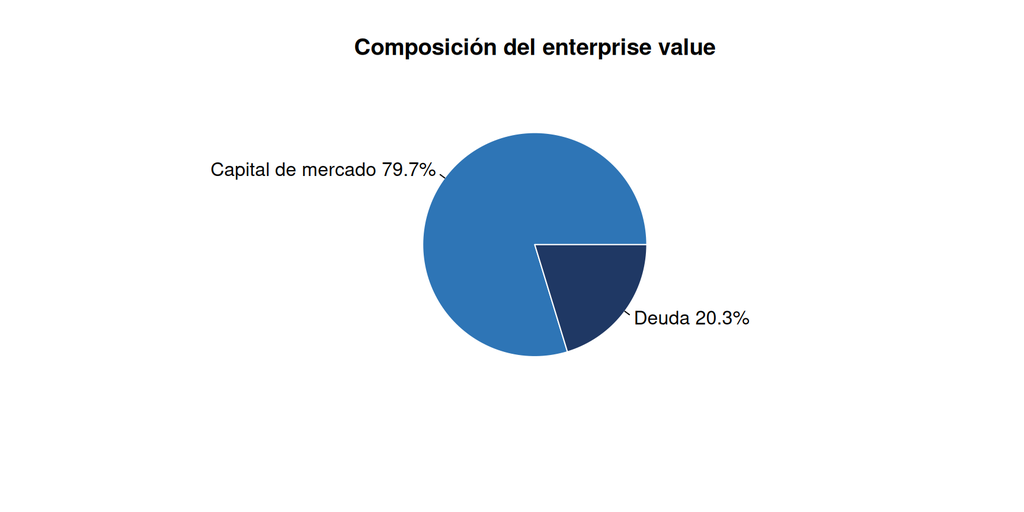

```r
pie(c(91767, 23356), labels = c("Capital de mercado 79.7%", "Deuda 20.3%"),
    col = c(azul2, azul), border = "white", main = "Composición del enterprise value")
```

## Perfil de deuda

```r
estructura <- data.frame(
  Instrumento = c("Bonos vigentes", "Préstamos (línea de crédito)", "Total", "Bonos inactivos (históricos)"),
  Emisiones = c(40, 1, 41, 1272),
  Monto_vigente_USD = c(17948298006, NA, 17948298006, NA),
  Monto_emitido_USD = c(21191891006, 3500000000, 24691891006, 28775591576)
)
tabla(estructura, "Debt Structure (DS) — LSEG")
```

Debt Structure (DS) — LSEG

| Instrumento | Emisiones | Monto_vigente_USD | Monto_emitido_USD |
| --- | --- | --- | --- |
| Bonos vigentes | 40 | 17,948,298,006 | 21,191,891,006 |
| Préstamos (línea de crédito) | 1 | NA | 3,500,000,000 |
| Total | 41 | 17,948,298,006 | 24,691,891,006 |
| Bonos inactivos (históricos) | 1,272 | NA | 28,775,591,576 |

```r
moneda <- data.frame(Moneda = c("Dólar estadounidense", "Dólar canadiense"),
                     Emisiones = c(39, 1), Vigente_USD_mm = c(17449.9, 498.4))
moneda$Participacion <- pct(moneda$Vigente_USD_mm / sum(moneda$Vigente_USD_mm), 1)
tabla(moneda, "Bonos por moneda")
```

Bonos por moneda

| Moneda | Emisiones | Vigente_USD_mm | Participacion |
| --- | --- | --- | --- |
| Dólar estadounidense | 39 | 17,449.9 | 97.2% |
| Dólar canadiense | 1 | 498.4 | 2.8% |

La deuda es casi 100% en dólares (97.2%), de tasa fija y senior no garantizada: el riesgo cambiario es marginal (solo un bono en CAD) y el riesgo relevante es de **tasa de interés y refinanciamiento**.

**Item 7A del 10-K 2025 (SEC):** al 31-dic-2025 WM tenía USD 22.9 mil millones de deuda de largo plazo y USD 2.9 mil millones expuestos a cambios de tasa en los siguientes 12 meses. Un alza de 100 pb elevaría su gasto por intereses en USD 35 mm y bajaría el valor justo de su deuda en cerca de USD 0.8 mil millones. Sus derivados vigentes eran inmateriales (la política está en la Nota 2 y la Nota 6 de deuda registra ajustes por derivados de tasa terminados).

## Bonos de WM en el mercado

```r
bonos <- data.frame(
  Cupon = c(7.00, 3.88, 4.88, 2.00, 4.63, 4.65, 1.50, 4.95, 4.80, 4.15, 7.75, 4.63, 4.88, 3.90,
            4.95, 6.13, 2.95, 4.10, 4.15, 2.50, 5.35),
  Vencimiento = as.Date(c("2028-07-15", "2029-01-15", "2029-02-15", "2029-06-01", "2030-02-15",
                          "2030-03-15", "2031-03-15", "2031-07-03", "2032-03-15", "2032-04-15",
                          "2032-05-15", "2033-02-15", "2034-02-15", "2035-03-01", "2035-03-15",
                          "2039-11-30", "2041-06-01", "2045-03-01", "2049-07-15", "2050-11-15",
                          "2054-10-15")),
  Precio_ask = c(102.833, 97.345, 99.433, 92.324, 98.040, 98.188, 85.162, 98.428, 97.176, 94.218,
                 108.825, 95.615, 96.216, 87.847, 95.478, 102.300, 70.970, 78.956, 76.100, 55.807, 90.737),
  YTM_ask = c(5.256, 5.149, 5.135, 5.187, 5.276, 5.238, 5.332, 5.331, 5.409, 5.383, 5.866, 5.454,
              5.509, 5.751, 5.633, 5.870, 5.953, 6.007, 6.108, 5.991, 6.040),
  Spread_bmk_pb = c(52.1, 40.2, 38.7, 35.5, 44.7, 41.0, 44.9, 44.9, 52.8, 50.2, 97.5, 49.4, 55.0,
                    78.2, 57.6, 81.4, 89.4, 60.4, 70.2, 58.4, 68.9)
)
bonos$Plazo_anios <- round(as.numeric(bonos$Vencimiento - as.Date("2026-10-21")) / 365.25, 1)
tabla(bonos, "Bonos constituyentes de la curva del emisor (Issuer Curve, cotización 21-oct-2026)")
```

Bonos constituyentes de la curva del emisor (Issuer Curve, cotización 21-oct-2026)

| Cupon | Vencimiento | Precio_ask | YTM_ask | Spread_bmk_pb | Plazo_anios |
| --- | --- | --- | --- | --- | --- |
| 7.00 | 2028-07-15 | 102.833 | 5.256 | 52.1 | 1.7 |
| 3.88 | 2029-01-15 | 97.345 | 5.149 | 40.2 | 2.2 |
| 4.88 | 2029-02-15 | 99.433 | 5.135 | 38.7 | 2.3 |
| 2.00 | 2029-06-01 | 92.324 | 5.187 | 35.5 | 2.6 |
| 4.63 | 2030-02-15 | 98.040 | 5.276 | 44.7 | 3.3 |
| 4.65 | 2030-03-15 | 98.188 | 5.238 | 41.0 | 3.4 |
| 1.50 | 2031-03-15 | 85.162 | 5.332 | 44.9 | 4.4 |
| 4.95 | 2031-07-03 | 98.428 | 5.331 | 44.9 | 4.7 |
| 4.80 | 2032-03-15 | 97.176 | 5.409 | 52.8 | 5.4 |
| 4.15 | 2032-04-15 | 94.218 | 5.383 | 50.2 | 5.5 |
| 7.75 | 2032-05-15 | 108.825 | 5.866 | 97.5 | 5.6 |
| 4.63 | 2033-02-15 | 95.615 | 5.454 | 49.4 | 6.3 |
| 4.88 | 2034-02-15 | 96.216 | 5.509 | 55.0 | 7.3 |
| 3.90 | 2035-03-01 | 87.847 | 5.751 | 78.2 | 8.4 |
| 4.95 | 2035-03-15 | 95.478 | 5.633 | 57.6 | 8.4 |
| 6.13 | 2039-11-30 | 102.300 | 5.870 | 81.4 | 13.1 |
| 2.95 | 2041-06-01 | 70.970 | 5.953 | 89.4 | 14.6 |
| 4.10 | 2045-03-01 | 78.956 | 6.007 | 60.4 | 18.4 |
| 4.15 | 2049-07-15 | 76.100 | 6.108 | 70.2 | 22.7 |
| 2.50 | 2050-11-15 | 55.807 | 5.991 | 58.4 | 24.1 |
| 5.35 | 2054-10-15 | 90.737 | 6.040 | 68.9 | 28.0 |

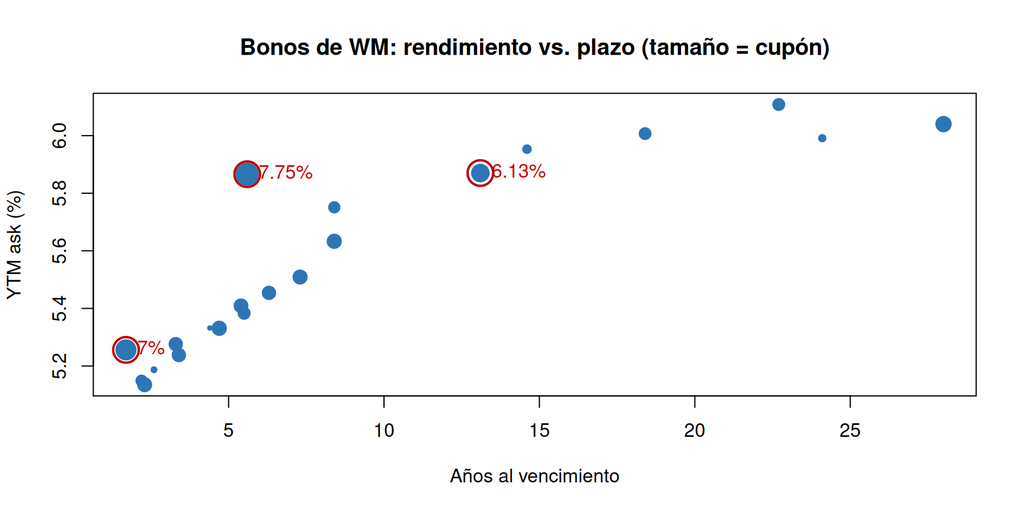

```r
plot(bonos$Plazo_anios, bonos$YTM_ask, pch = 19, cex = bonos$Cupon / 3, col = azul2,
     xlab = "Años al vencimiento", ylab = "YTM ask (%)",
     main = "Bonos de WM: rendimiento vs. plazo (tamaño = cupón)")
alto <- bonos$Cupon >= 6
points(bonos$Plazo_anios[alto], bonos$YTM_ask[alto], pch = 1, cex = 3, col = rojo, lwd = 2)
text(bonos$Plazo_anios[alto], bonos$YTM_ask[alto], paste0(bonos$Cupon[alto], "%"), pos = 4, col = rojo)
```

## Bonos a recomprar

```r
print(tabla(recompra, "Candidatos a recompra (montos vigentes: páginas de cada bono en LSEG; Prima_tender = supuesto de 1 punto)"))
```

Candidatos a recompra (montos vigentes: páginas de cada bono en LSEG; Prima_tender = supuesto de 1 punto)

| Bono | ISIN | Cupon | Nominal_mm | Precio_ask | Prima_tender | Costo_tender_mm | Cupon_anual_mm |
| --- | --- | --- | --- | --- | --- | --- | --- |
| WM 7.00% 15-jul-2028 | US902917AH67 | 0.07000 | 257.907 | 102.8405 | 1 | 267.8119 | 18.05349 |
| WM 7.75% 15-may-2032 | US94106LAN91 | 0.07750 | 143.621 | 108.8381 | 1 | 157.7506 | 11.13063 |
| WM 6.125% 30-nov-2039 | US94106LAV18 | 0.06125 | 245.686 | 102.2998 | 1 | 253.7931 | 15.04827 |

```r
cat("\n\nNominal total:", usd(sum(recompra$Nominal_mm), 1), "mm | Costo del tender:",
    usd(tender, 1), "mm | Cupón anual que se elimina:",
    usd(cup_elim, 1), "mm | Cupón promedio:",
    pct(cup_elim / sum(recompra$Nominal_mm)), "\n\n")
```

Nominal total: $647.2 mm | Costo del tender: $679.4 mm | Cupón anual que se elimina: $44.2 mm | Cupón promedio: 6.83%

# 5. Calificación y riesgo de crédito

## Calificaciones

```r
calif <- data.frame(
  Agencia = c("S&P (emisor, largo plazo)", "Fitch (emisor, largo plazo)", "Moody's (emisor, largo plazo)",
              "Moody's (deuda senior respaldada / derivada)", "Egan-Jones (bonos senior)"),
  Calificacion = c("A-", "A-", "WR (retirada)", "A3", "BBB"),
  Fecha = c("Afirmada 04-jun-2024", "Afirmada 13-ago-2026", "07-may-2018", "30-oct-2025", "17-ago-2026"),
  Comentario = c("Grado de inversión, perspectiva estable", "Grado de inversión", "Calificación de emisor retirada",
                 "Moody's sí califica la deuda senior respaldada y da una calificación derivada", "Agencia menor; reportada en la pantalla de cada bono")
)
tabla(calif, "Calificaciones crediticias (LSEG: Issuer Ratings, captura del 03-nov-2026 en el Anexo A)")
```

Calificaciones crediticias (LSEG: Issuer Ratings, captura del 03-nov-2026 en el Anexo A)

| Agencia | Calificacion | Fecha | Comentario |
| --- | --- | --- | --- |
| S&P (emisor, largo plazo) | A- | Afirmada 04-jun-2024 | Grado de inversión, perspectiva estable |
| Fitch (emisor, largo plazo) | A- | Afirmada 13-ago-2026 | Grado de inversión |
| Moody’s (emisor, largo plazo) | WR (retirada) | 07-may-2018 | Calificación de emisor retirada |
| Moody’s (deuda senior respaldada / derivada) | A3 | 30-oct-2025 | Moody’s sí califica la deuda senior respaldada y da una calificación derivada |
| Egan-Jones (bonos senior) | BBB | 17-ago-2026 | Agencia menor; reportada en la pantalla de cada bono |

Un emisor **A-** con cobertura de intereses de 8.7x tiene acceso amplio al mercado; por eso el convertible se valúa descontando el bono directo a la curva de WM (spread ~66 pb sobre Treasuries a 6 años) y no a una tasa high-yield.

## Curva del emisor y probabilidad de incumplimiento

```r
curva <- data.frame(
  Plazo = c(1, 2, 3, 4, 5, 6, 7, 8, 9, 10, 12, 15, 20, 25, 30),
  Yield = c(5.363, 5.292, 5.350, 5.454, 5.559, 5.649, 5.722, 5.783, 5.838, 5.886, 5.967, 6.060, 6.145, 6.170, 6.164),
  Spread_bmk = c(88.3, 48.6, 46.1, 52.9, 60.9, 65.7, 69.3, 72.0, 74.5, 76.8, 76.8, 73.8, 67.9, 71.7, 75.5),
  Z_spread = c(97.1, 74.9, 79.1, 91.0, 102.6, 111.9, 118.8, 124.1, 128.3, 131.5, 135.9, 140.3, 145.8, 150.8, 154.8),
  Prob_default = c(0.864, 1.276, 2.086, 3.359, 4.893, 6.465, 8.109, 9.746, 11.332, 12.866, 15.817, 20.136, 27.367, 35.026, 42.755)
)
curva$Treasury <- curva$Yield - curva$Spread_bmk / 100
tabla(curva, "Issuer Curve 0#WMUSDABMK= (yield %, spreads en pb, probabilidad de default acumulada %)")
```

Issuer Curve 0#WMUSDABMK= (yield %, spreads en pb, probabilidad de default acumulada %)

| Plazo | Yield | Spread_bmk | Z_spread | Prob_default | Treasury |
| --- | --- | --- | --- | --- | --- |
| 1 | 5.363 | 88.3 | 97.1 | 0.864 | 4.480 |
| 2 | 5.292 | 48.6 | 74.9 | 1.276 | 4.806 |
| 3 | 5.350 | 46.1 | 79.1 | 2.086 | 4.889 |
| 4 | 5.454 | 52.9 | 91.0 | 3.359 | 4.925 |
| 5 | 5.559 | 60.9 | 102.6 | 4.893 | 4.950 |
| 6 | 5.649 | 65.7 | 111.9 | 6.465 | 4.992 |
| 7 | 5.722 | 69.3 | 118.8 | 8.109 | 5.029 |
| 8 | 5.783 | 72.0 | 124.1 | 9.746 | 5.063 |
| 9 | 5.838 | 74.5 | 128.3 | 11.332 | 5.093 |
| 10 | 5.886 | 76.8 | 131.5 | 12.866 | 5.118 |
| 12 | 5.967 | 76.8 | 135.9 | 15.817 | 5.199 |
| 15 | 6.060 | 73.8 | 140.3 | 20.136 | 5.322 |
| 20 | 6.145 | 67.9 | 145.8 | 27.367 | 5.466 |
| 25 | 6.170 | 71.7 | 150.8 | 35.026 | 5.453 |
| 30 | 6.164 | 75.5 | 154.8 | 42.755 | 5.409 |

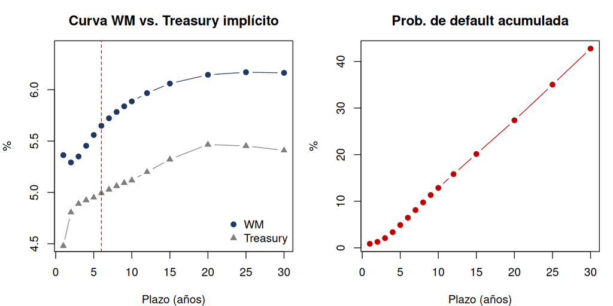

```r
par(mfrow = c(1, 2), mar = c(4, 4, 3, 1))
plot(curva$Plazo, curva$Yield, type = "b", pch = 19, col = azul, ylim = c(4.5, 6.4),
     xlab = "Plazo (años)", ylab = "%", main = "Curva WM vs. Treasury implícito")
lines(curva$Plazo, curva$Treasury, type = "b", pch = 17, col = gris)
abline(v = 6, lty = 2, col = rojo)
legend("bottomright", c("WM", "Treasury"), col = c(azul, gris), pch = c(19, 17), bty = "n")
plot(curva$Plazo, curva$Prob_default, type = "b", pch = 19, col = rojo,
     xlab = "Plazo (años)", ylab = "%", main = "Prob. de default acumulada")
```

```r
par(mfrow = c(1, 1))
```

A 6 años (plazo del convertible): rendimiento de **5.649%**, spread de **65.7 pb** y probabilidad de incumplimiento acumulada de **6.5%** implícita en precios de mercado.

# 6. Tasas y volatilidad implícita

## Tasas

```r
tabla(data.frame(
  Insumo = c("Treasury 5 años (US5YT=RR)", "Treasury 7 años (US7YT=RR)",
             "Tasa libre de riesgo 6 años (interpolada)", "Tasa de descuento: YTM WM 6 años",
             "Dividend yield (continuo, supuesto constante)"),
  Valor = c(pct(ust5, 3), pct(ust7, 3), pct(rf, 3), pct(y_wm, 3), pct(q, 2))), "Tasas de mercado al 21-oct-2026")
```

Tasas de mercado al 21-oct-2026

| Insumo | Valor |
| --- | --- |
| Treasury 5 años (US5YT=RR) | 4.918% |
| Treasury 7 años (US7YT=RR) | 4.995% |
| Tasa libre de riesgo 6 años (interpolada) | 4.957% |
| Tasa de descuento: YTM WM 6 años | 5.649% |
| Dividend yield (continuo, supuesto constante) | 1.63% |

## Volatilidad implícita

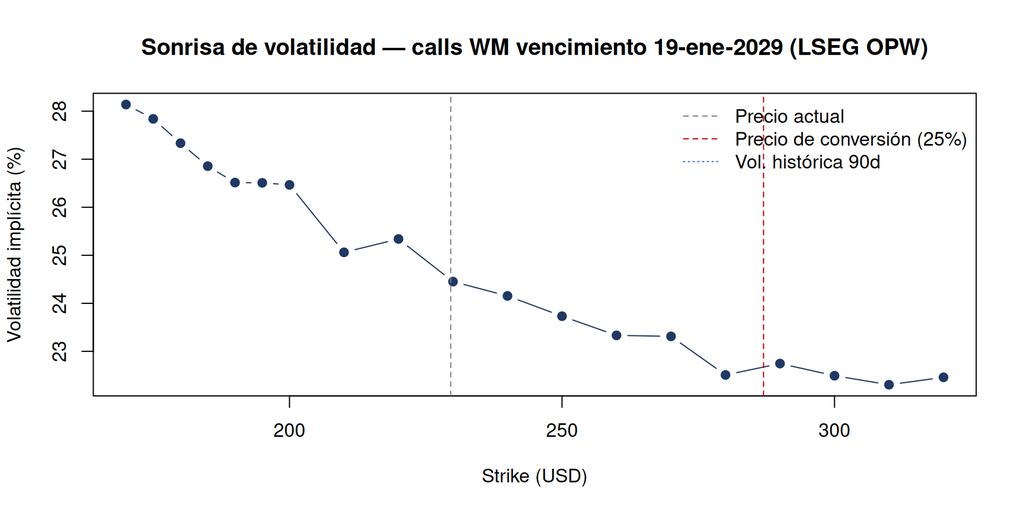

```r
iv <- data.frame(
  Strike = c(170, 175, 180, 185, 190, 195, 200, 210, 220, 230, 240, 250, 260, 270, 280, 290, 300, 310, 320),
  IV = c(28.1390, 27.8401, 27.3338, 26.8558, 26.5135, 26.5080, 26.4654, 25.0615, 25.3394, 24.4515,
         24.1535, 23.7319, 23.3327, 23.3120, 22.5082, 22.7453, 22.4926, 22.3048, 22.4595),
  Delta = c(0.8592, 0.8456, 0.8305, 0.8149, 0.7983, 0.7800, 0.7609, 0.7242, 0.6813, 0.6380, 0.5927,
            0.5470, 0.5006, 0.4561, 0.4089, 0.3704, 0.3305, 0.2941, 0.2624)
)
plot(iv$Strike, iv$IV, type = "b", pch = 19, col = azul,
     xlab = "Strike (USD)", ylab = "Volatilidad implícita (%)",
     main = "Sonrisa de volatilidad — calls WM vencimiento 19-ene-2029 (LSEG OPW)")
abline(v = c(precio, K), lty = 2, col = c(gris, rojo))
abline(h = 21.04, lty = 3, col = azul2)
legend("topright", c("Precio actual", "Precio de conversión (25%)", "Vol. histórica 90d"),
       col = c(gris, rojo, azul2), lty = c(2, 2, 3), bty = "n")
```

El LEAPS más largo vence en ene-2029. Para la opción de conversión usamos la vol. implícita del strike 290 (≈ precio de conversión): **22.75%**. Para el warrant usamos la histórica de 90 días (**21.04%**), siguiendo al caso, que valúa el warrant con una volatilidad menor (21% vs. 23%). La sonrisa tiene pendiente negativa (*skew*): los strikes altos —donde viven la conversión y el warrant— tienen menor volatilidad implícita que los strikes en el dinero.

# 7. Estimación de volatilidad: EWMA y GARCH(1,1) (Hull, cap. 23)

La opción de conversión dura 6 años, pero las opciones listadas solo llegan a 2.2 años. Para validar la volatilidad de largo plazo estimamos, con precios diarios de WM, los modelos del capítulo 23 de Hull:

- **EWMA** (RiskMetrics, λ = 0.94): $\sigma_n^2 = \lambda\sigma_{n-1}^2 + (1-\lambda)u_{n-1}^2$ (ec. 23.7).
- **GARCH(1,1)**: $\sigma_n^2 = \omega + \alpha u_{n-1}^2 + \beta\sigma_{n-1}^2$, con varianza de largo plazo $V_L = \omega/(1-\alpha-\beta)$, parámetros por **máxima verosimilitud** (maximizar $\sum[-\ln v_i - u_i^2/v_i]$).
- **Estructura temporal** (ec. 23.13): volatilidad promedio para un plazo de $T$ días, $\sigma(T)^2 = 252\left[V_L + \frac{1-e^{-aT}}{aT}\left(V(0)-V_L\right)\right]$, con $a=\ln\frac{1}{\alpha+\beta}$.

```r
archivo_precios <- "datos/WM_precios.csv"   # exportado de LSEG (Price History) o del notebook de Colab
hay_precios <- file.exists(archivo_precios)
```

```r
leer_precios <- function(f) {
  x <- read.csv(f, stringsAsFactors = FALSE, check.names = FALSE)
  nm <- names(x)
  cf <- grep("date|fecha", nm, ignore.case = TRUE)[1]; if (is.na(cf)) cf <- 1
  cp <- setdiff(grep("close|cierre|price|precio|last", nm, ignore.case = TRUE), cf)[1]
  if (is.na(cp)) cp <- 2
  txt <- trimws(as.character(x[[cf]]))
  formatos <- c("%Y-%m-%d", "%d-%b-%Y", "%m/%d/%Y", "%d/%m/%Y", "%d-%m-%Y", "%b %d, %Y", "%d.%m.%Y")
  intentos <- lapply(formatos, function(fmt) as.Date(txt, format = fmt))
  fecha <- intentos[[which.min(sapply(intentos, function(d) sum(is.na(d))))]]
  cierre <- as.numeric(gsub("[^0-9.\\-]", "", as.character(x[[cp]])))
  df <- data.frame(Fecha = fecha, Cierre = cierre)
  df <- df[!is.na(df$Fecha) & !is.na(df$Cierre) & df$Cierre > 0, ]
  df <- df[!duplicated(df$Fecha), ]
  df[order(df$Fecha), ]
}
px <- leer_precios(archivo_precios)
# Misma convención que el notebook de clase (garch_derivados): u_i = 100 ln(S_i / S_{i-1}), en %
u  <- 100 * diff(log(px$Cierre))
nu <- length(u)
anual <- function(v) sqrt(252 * v) / 100          # varianza diaria en %^2 -> volatilidad anual (decimal)

# Volatilidad histórica (Hull 23.1)
vol_hist    <- sd(u) * sqrt(252) / 100
vol_hist_1a <- sd(tail(u, 252)) * sqrt(252) / 100

# GARCH(1,1): v[t] = w + a u[t-1]^2 + b v[t-1], con v[1] = varianza muestral (como el notebook)
var_garch <- function(w, a, b, v0 = var(u)) {
  x <- w + a * u[-nu]^2
  c(v0, as.numeric(stats::filter(x, b, method = "recursive", init = v0)))
}
var_ewma <- function(lam = 0.94) var_garch(0, 1 - lam, lam, v0 = var(u[1:30]))
loglik   <- function(v) -0.5 * sum(log(2 * pi) + log(v) + u^2 / v)       # Hull 23.5

# Máxima verosimilitud. Reparametrización para garantizar w > 0, a > 0, b > 0 y a + b < 1
transforma <- function(th) { e2 <- exp(th[2]); e3 <- exp(th[3])
  c(w = exp(th[1]), a = e2 / (1 + e2 + e3), b = e3 / (1 + e2 + e3)) }
neg_ll <- function(th) { p <- transforma(th); -loglik(var_garch(p[1], p[2], p[3])) }
th0 <- c(log(var(u) * 0.03), log(0.08 / 0.02), log(0.90 / 0.02))   # a = 0.08, b = 0.90 (mismo inicio que el notebook)
opt <- optim(th0, neg_ll, method = "Nelder-Mead", control = list(maxit = 5000, reltol = 1e-12))
opt <- optim(opt$par, neg_ll, method = "BFGS")                       # pulido final
par_g <- transforma(opt$par)
w_g <- unname(par_g["w"]); a_g <- unname(par_g["a"]); b_g <- unname(par_g["b"])
VL  <- w_g / (1 - a_g - b_g)
v_g <- var_garch(w_g, a_g, b_g)
V0  <- w_g + a_g * u[nu]^2 + b_g * v_g[nu]                         # varianza para mañana
v_ew <- var_ewma(0.94)
v_e_hoy <- 0.94 * v_ew[nu] + 0.06 * u[nu]^2

# Pronóstico (Hull 23.6): E[v_{n+k}] = V_L + (a+b)^k (V0 - V_L); volatilidad promedio para T días
vol_promedio <- function(dias) { k <- 0:(max(round(dias), 1) - 1); anual(mean(VL + (a_g + b_g)^k * (V0 - VL))) }
a_r <- log(1 / (a_g + b_g))
vol_hull <- function(dias) anual(VL + (1 - exp(-a_r * dias)) / (a_r * dias) * (V0 - VL))   # ec. 23.13
vol_garch6 <- vol_promedio(252 * Tm)

tabla(data.frame(
  Concepto = c("Observaciones (días)", "Periodo", "Vol. histórica toda la muestra", "Vol. histórica último año",
               "EWMA λ=0.94: vol. actual", "GARCH ω (%²)", "GARCH α", "GARCH β", "Persistencia α+β",
               "Vol. de largo plazo √(252·V_L)", "GARCH: vol. actual", "Vida media de un choque (días)",
               "GARCH: vol. promedio LEAPS (554 días)", "GARCH: vol. promedio 6 años (1,512 días)",
               "Control ec. 23.13 de Hull (6 años)", "Log-verosimilitud"),
  Valor = c(nu, paste(format(min(px$Fecha), "%d-%b-%Y"), "a", format(max(px$Fecha), "%d-%b-%Y")),
            pct(vol_hist), pct(vol_hist_1a), pct(anual(v_e_hoy)), round(w_g, 5),
            round(a_g, 4), round(b_g, 4), round(a_g + b_g, 4), pct(anual(VL)),
            pct(anual(V0)), round(log(0.5) / log(a_g + b_g)), pct(vol_promedio(554)), pct(vol_garch6),
            pct(vol_hull(252 * Tm)), round(-opt$value, 1))), "Estimación de volatilidad con precios diarios de WM")
```

Estimación de volatilidad con precios diarios de WM

| Concepto | Valor |
| --- | --- |
| Observaciones (días) | 1254 |
| Periodo | 03-Nov-2021 a 03-Nov-2026 |
| Vol. histórica toda la muestra | 19.34% |
| Vol. histórica último año | 21.18% |
| EWMA λ=0.94: vol. actual | 29.76% |
| GARCH ω (%²) | 0.50031 |
| GARCH α | 0.1352 |
| GARCH β | 0.5387 |
| Persistencia α+β | 0.6739 |
| Vol. de largo plazo √(252·V_L) | 19.66% |
| GARCH: vol. actual | 21.77% |
| Vida media de un choque (días) | 2 |
| GARCH: vol. promedio LEAPS (554 días) | 19.68% |
| GARCH: vol. promedio 6 años (1,512 días) | 19.67% |
| Control ec. 23.13 de Hull (6 años) | 19.67% |
| Log-verosimilitud | -2010.3 |

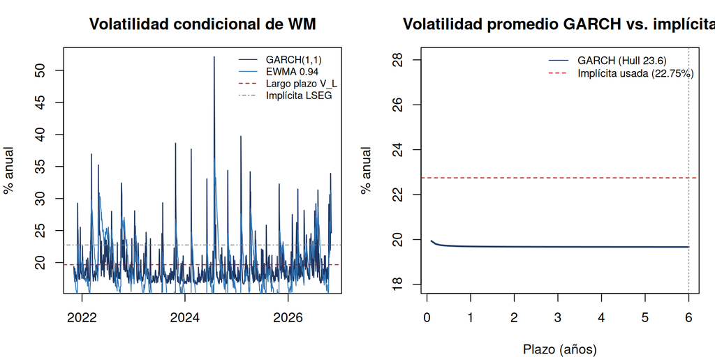

```r
par(mfrow = c(1, 2), mar = c(4, 4, 3, 1))
fx <- px$Fecha[-1]
plot(fx, anual(v_g) * 100, type = "l", col = azul, lwd = 1.3, xlab = "", ylab = "% anual",
     main = "Volatilidad condicional de WM")
lines(fx, anual(v_ew) * 100, col = azul2, lwd = 1)
abline(h = anual(VL) * 100, lty = 2, col = rojo); abline(h = s_c * 100, lty = 4, col = gris)
legend("topright", c("GARCH(1,1)", "EWMA 0.94", "Largo plazo V_L", "Implícita LSEG"), col = c(azul, azul2, rojo, gris),
       lty = c(1, 1, 2, 4), bty = "n", cex = 0.75)
plazos <- seq(0.1, 6, by = 0.1)
vp <- sapply(plazos * 252, vol_promedio) * 100
plot(plazos, vp, type = "l", lwd = 2, col = azul, xlab = "Plazo (años)",
     ylab = "% anual", main = "Volatilidad promedio GARCH vs. implícita", ylim = range(c(vp, iv$IV, 18, 28)))
abline(h = s_c * 100, lty = 2, col = rojo); abline(v = Tm, lty = 3, col = gris)
legend("topright", c("GARCH (Hull 23.6)", "Implícita usada (22.75%)"), col = c(azul, rojo),
       lty = c(1, 2), bty = "n", cex = 0.8)
```

```r
par(mfrow = c(1, 1))
```

**¿Qué modelo elegir? (Hull 23.4).** Log-verosimilitud (más alta es mejor), AIC/BIC (más bajo es mejor) y prueba de Ljung-Box sobre $u^2/\sigma^2$: si p > 0.05 el modelo ya capturó el *clustering* de volatilidad.

```r
lams <- seq(0.80, 0.99, by = 0.005)
lam_opt <- lams[which.max(sapply(lams, function(l) loglik(var_ewma(l))))]
modelos <- list("Volatilidad constante" = list(v = rep(var(u), nu), k = 1),
                "EWMA λ=0.94" = list(v = v_ew, k = 0),
                "EWMA λ óptimo" = list(v = var_ewma(lam_opt), k = 1),
                "GARCH(1,1)" = list(v = v_g, k = 3))
comp <- do.call(rbind, lapply(names(modelos), function(m) { v <- modelos[[m]]$v; k <- modelos[[m]]$k; ll <- loglik(v)
  data.frame(Modelo = ifelse(m == "EWMA λ óptimo", paste0(m, " (", lam_opt, ")"), m), Log_verosimilitud = round(ll, 1),
             AIC = round(2 * k - 2 * ll, 1), BIC = round(k * log(nu) - 2 * ll, 1),
             p_Ljung_Box = round(Box.test(u^2 / v, lag = 10, type = "Ljung-Box")$p.value, 3)) }))
print(tabla(comp, "Comparación de modelos de volatilidad para WM"))
```

Comparación de modelos de volatilidad para WM

| Modelo | Log_verosimilitud | AIC | BIC | p_Ljung_Box |
| --- | --- | --- | --- | --- |
| Volatilidad constante | -2,027.4 | 4,056.8 | 4,061.9 | 0.189 |
| EWMA λ=0.94 | -2,089.6 | 4,179.3 | 4,179.3 | 0.997 |
| EWMA λ óptimo (0.99) | -2,038.6 | 4,079.2 | 4,084.3 | 0.879 |
| GARCH(1,1) | -2,010.3 | 4,026.5 | 4,041.9 | 0.967 |

```r
cat("\n\nLjung-Box de u² sin modelar (p pequeño = hay clustering):",
    round(Box.test(u^2, lag = 10, type = "Ljung-Box")$p.value, 4), "\n\n")
```

Ljung-Box de u² sin modelar (p pequeño = hay clustering): 0.1891

**Lectura:** la persistencia α+β = 0.674 indica que los choques de volatilidad se disipan con una vida media de ~2 días, por lo que a 6 años la volatilidad converge a la de largo plazo (19.66%). La volatilidad GARCH promedio a 6 años es **19.67%**, frente a la implícita de 22.75%. Con la volatilidad GARCH, el cupón a la par del convertible sería **2.85%** (vs. 2.41% en el caso base). Si GARCH queda por debajo de la implícita, el mercado paga cara la opción que WM vende, lo que favorece emitir. El notebook de Colab (`notebooks/WM_GARCH_Derivados.ipynb`) replica esta estimación y agrega back testing del VaR, Monte Carlo GARCH a 6 años y la comprobación árbol vs. Monte Carlo.

**Resultados con datos reales (corrida del notebook de Colab con precios de Yahoo Finance hasta el 28-oct-2026):** la tabla siguiente es esa corrida. La estimación en R de arriba usa precios hasta el 03-nov-2026; por eso la “volatilidad de hoy” es distinta, mientras que la volatilidad de largo plazo y el promedio a 6 años (≈19.7%) prácticamente no cambian.

| Concepto | WM | RSG |
| --- | --- | --- |
| α / β | 0.135 / 0.545 | 0.268 / 0.436 |
| Persistencia α+β | 0.680 | 0.704 |
| Vida media de un choque | ~2 días | ~2 días |
| Vol. de largo plazo | 19.7% | 19.6% |
| Vol. hoy (GARCH) | 33.9% | 22.2% |
| Vol. promedio a 6 años | **19.7%** | 19.6% |

La estimación propia coincide con el paquete `arch` (WM: α = 0.1336, β = 0.5497). La persistencia es baja para una acción (lo típico es 0.95-0.99): la volatilidad de WM no se agrupa en rachas largas sino en **saltos aislados, más o menos trimestrales, que coinciden con los reportes de resultados** y se disipan en un par de días. Por eso el 33.9% del 28-oct (caída de -4.5% ese día) no afecta a 6 años: la volatilidad promedio converge a 19.7%.

| Volatilidad usada | σ | Cupón bono + call (caso) | Cupón árbol T-F | Ahorro vs. bono directo |
| --- | --- | --- | --- | --- |
| Histórica 1 año | 21.75% | 2.75% | 2.56% | 309 pb |
| GARCH promedio 6 años | 19.70% | 3.03% | 2.85% | 280 pb |
| **Implícita LSEG (caso base)** | **22.75%** | **2.61%** | **2.41%** | **324 pb** |
| Implícita Yahoo (LEAPS) | 26.92% | 2.04% | 1.79% | 386 pb |

- **Señal:** σ GARCH / σ implícita = 0.87 (< 0.90) → **EMITIR**. El mercado cobra la volatilidad más cara de lo que GARCH espera, y WM es quien la vende al emitir el convertible.
- **Back testing del VaR (Kupiec, 502 días):** al 95% todos los modelos pasan. Al 99%, GARCH y EWMA fallan por muy poco en WM (10 excepciones vs. 5 esperadas, p = 0.049): hay **colas más pesadas que la normal**, la limitación de GARCH(1,1) que señala Hull (una extensión sería GARCH con distribución t). Esto afecta el VaR de 1 día, no la volatilidad promedio de 6 años, pero aconseja no valuar con una volatilidad baja: por eso el caso base usa la implícita de LSEG y GARCH queda como contraste.
- **Dilución (Monte Carlo GARCH, 6 años, rendimiento esperado supuesto de 8% anual):** probabilidad de que WM supere el precio de conversión de 62.3%, y el strike del warrant de 42.5%. El call spread baja la dilución esperada al vencimiento de USD 307 mm a USD 198 mm.

# 8. Valuación de la opción de conversión

## Black-Scholes: avance vs. final

En el avance valuamos la opción **sin dividendo**. WM paga un dividendo de 1.63% anual que el tenedor del convertible no recibe, por lo que la opción de conversión vale menos y el emisor debe pagar un cupón mayor. La versión final incorpora el dividendo con Black-Scholes-Merton ($Se^{-qT}$).

```r
tabla(data.frame(
  Concepto = c("Call por acción", "Delta", "Opción de conversión por bono", "Bono directo por bono",
               "Cupón que deja el convertible a la par", "Costo note hedge (USD mm)",
               "Ingreso warrants al 60% (USD mm)", "Costo neto call spread (USD mm)", "Costo neto / principal"),
  Avance_sin_dividendo = c(usd(call0["precio"], 2), round(call0["delta"], 3), usd(opcion0, 2), usd(1000 - opcion0, 2),
                           pct(cupon0, 3), usd(hedge0, 1), usd(warr0, 1), usd(hedge0 - warr0, 1), pct((hedge0 - warr0) / monto, 1)),
  Final_con_dividendo = c(usd(callq["precio"], 2), round(callq["delta"], 3), usd(opcionq, 2), usd(1000 - opcionq, 2),
                          pct(cuponq, 3), usd(hedge, 1), usd(warr, 1), usd(neto_cs, 1), pct(neto_cs / monto, 1))
), "Black-Scholes (Exhibits 2-4 del caso aplicados a WM)")
```

Black-Scholes (Exhibits 2-4 del caso aplicados a WM)

| Concepto | Avance_sin_dividendo | Final_con_dividendo |
| --- | --- | --- |
| Call por acción | $57.21 | $43.79 |
| Delta | 0.66 | 0.538 |
| Opción de conversión por bono | $199.35 | $152.58 |
| Bono directo por bono | $800.65 | $847.42 |
| Cupón que deja el convertible a la par | 1.685% | 2.615% |
| Costo note hedge (USD mm) | $149.5 | $114.4 |
| Ingreso warrants al 60% (USD mm) | $84.2 | $60.0 |
| Costo neto call spread (USD mm) | $65.3 | $54.4 |
| Costo neto / principal | 8.7% | 7.3% |

## Árbol binomial CRR y convergencia

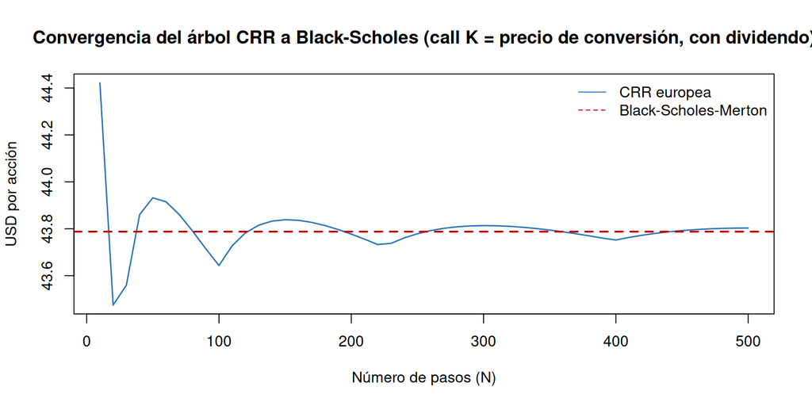

```r
pasos <- seq(10, 500, by = 10)
eur <- sapply(pasos, function(N) crr_call(precio, K, rf, s_c, Tm, N, q))
ame <- sapply(c(12, 72, 360), function(N) crr_call(precio, K, rf, s_c, Tm, N, q, americana = TRUE))
plot(pasos, eur, type = "l", col = azul2, lwd = 1.5, xlab = "Número de pasos (N)", ylab = "USD por acción",
     main = "Convergencia del árbol CRR a Black-Scholes (call K = precio de conversión, con dividendo)")
abline(h = callq["precio"], col = rojo, lty = 2, lwd = 2)
legend("topright", c("CRR europea", "Black-Scholes-Merton"), col = c(azul2, rojo), lty = c(1, 2), bty = "n")
```

```r
tabla(data.frame(
  Pasos = c(12, 72, 360),
  dt = c("6 meses", "1 mes", "~1 semana"),
  CRR_europea = round(sapply(c(12, 72, 360), function(N) crr_call(precio, K, rf, s_c, Tm, N, q)), 4),
  CRR_americana = round(ame, 4),
  Black_Scholes = round(unname(callq["precio"]), 4)), "Call por acción: árbol vs. fórmula")
```

Call por acción: árbol vs. fórmula

| Pasos | dt | CRR_europea | CRR_americana | Black_Scholes |
| --- | --- | --- | --- | --- |
| 12 | 6 meses | 44.1645 | 44.1740 | 43.7876 |
| 72 | 1 mes | 43.8472 | 43.8671 | 43.7876 |
| 360 | ~1 semana | 43.7870 | 43.8088 | 43.7876 |

Con 360 pasos el árbol difiere de Black-Scholes en centavos. La versión americana vale un poco más porque, con dividendo, puede convenir ejercer antes: esa es la razón para valuar el convertible completo en el árbol y no con la fórmula europea.

## Árbol de 6 pasos (ilustrativo)

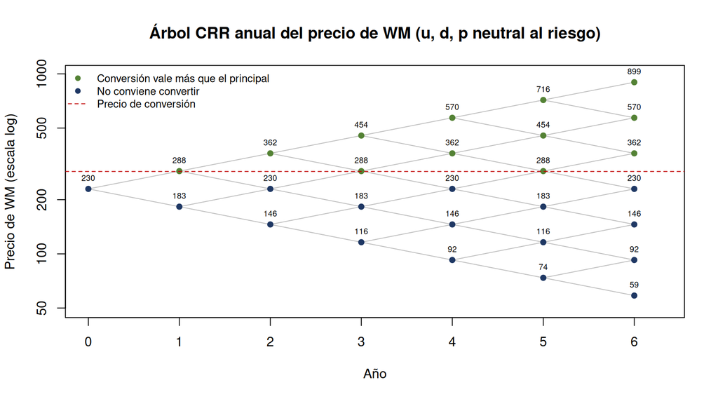

```r
N6 <- 6; dt6 <- Tm / N6; u6 <- exp(s_c * sqrt(dt6)); d6 <- 1 / u6
p6 <- (exp((rf - q) * dt6) - d6) / (u6 - d6)
plot(NA, xlim = c(0, N6 + 0.3), ylim = c(precio * d6^N6 * 0.85, precio * u6^N6 * 1.1), log = "y",
     xlab = "Año", ylab = "Precio de WM (escala log)", main = "Árbol CRR anual del precio de WM (u, d, p neutral al riesgo)")
for (i in 0:N6) for (j in 0:i) {
  S_ij <- precio * u6^(i - j) * d6^j
  if (i < N6) segments(i, S_ij, i + 1, c(S_ij * u6, S_ij * d6), col = "#BFBFBF")
  points(i, S_ij, pch = 19, col = ifelse(S_ij * n > 1000, verde, azul), cex = 0.9)
  text(i, S_ij, round(S_ij), pos = 3, cex = 0.6)
}
abline(h = K, lty = 2, col = rojo)
legend("topleft", c("Conversión vale más que el principal", "No conviene convertir", "Precio de conversión"),
       col = c(verde, azul, rojo), pch = c(19, 19, NA), lty = c(NA, NA, 2), bty = "n", cex = 0.8)
```

```r
cat("\n\nu =", round(u6, 4), "| d =", round(d6, 4), "| p =", round(p6, 4), "\n\n")
```

u = 1.2554 | d = 0.7966 | p = 0.5171

# 9. Valuación del convertible completo en el árbol

El enfoque del caso (bono directo + call europea) ignora dos cosas: la **conversión anticipada** (que con dividendos tiene valor) y que el componente de acciones no tiene riesgo de crédito. Usamos el método de **Tsiveriotis-Fernandes**: en cada nodo el valor del convertible se divide en una parte en efectivo (cupones y principal, descontada a la YTM de WM, 5.649%) y una parte en acciones (descontada a la libre de riesgo, 4.957%). El tenedor convierte cuando $n \cdot S$ supera el valor de continuar. Árbol de 360 pasos (60 por año, cupón semestral cada 30 pasos).

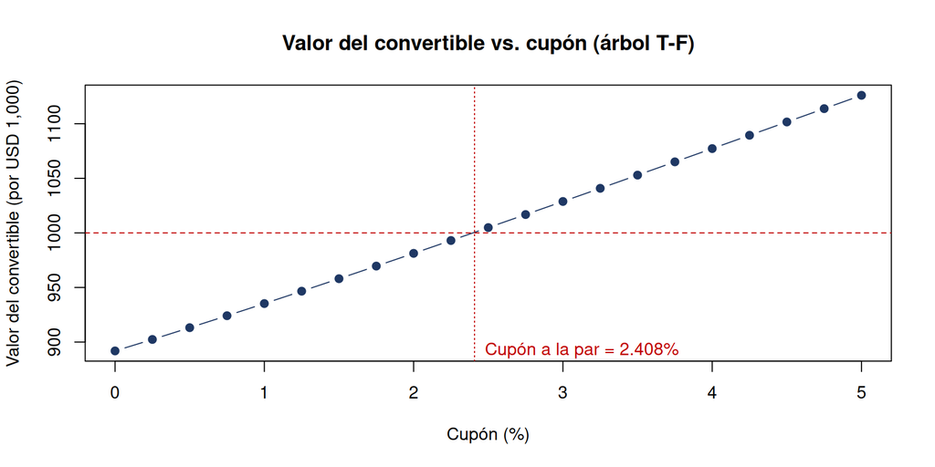

```r
cupones_prueba <- seq(0, 0.05, by = 0.0025)
valores <- sapply(cupones_prueba, function(cc) tf_convertible(cc, N = 180))
plot(cupones_prueba * 100, valores, type = "b", pch = 19, col = azul, xlab = "Cupón (%)",
     ylab = "Valor del convertible (por USD 1,000)", main = "Valor del convertible vs. cupón (árbol T-F)")
abline(h = 1000, lty = 2, col = rojo); abline(v = cupon_tf * 100, lty = 3, col = rojo)
text(cupon_tf * 100, min(valores), paste0("Cupón a la par = ", pct(cupon_tf, 3)), pos = 4, col = rojo)
```

```r
tabla(data.frame(
  Metodo = c("Avance: B-S sin dividendo", "B-S con dividendo (europea)", "Árbol T-F con dividendo y conversión anticipada",
             "Referencia: cupón real de Molson (2007)"),
  Cupon_a_la_par = c(pct(cupon0, 3), pct(cuponq, 3), pct(cupon_tf, 3), "2.500%"),
  Ahorro_vs_bono_directo_pb = c(round((y_wm - cupon0) * 1e4), round((y_wm - cuponq) * 1e4),
                                round((y_wm - cupon_tf) * 1e4), NA)), "Cupón que deja el convertible a la par")
```

Cupón que deja el convertible a la par

| Metodo | Cupon_a_la_par | Ahorro_vs_bono_directo_pb |
| --- | --- | --- |
| Avance: B-S sin dividendo | 1.685% | 396 |
| B-S con dividendo (europea) | 2.615% | 303 |
| Árbol T-F con dividendo y conversión anticipada | 2.408% | 324 |
| Referencia: cupón real de Molson (2007) | 2.500% | NA |

**Lectura:** el cupón del caso base sube de 1.69% (avance) a **2.41%**. El dividendo reduce el valor de la opción europea; la conversión anticipada le devuelve parte del valor. El resultado queda muy cerca del 2.5% con que Molson colocó su convertible.

# 10. El call spread

## Costo y prima efectiva

```r
tabla(data.frame(
  Concepto = c("Strike note hedge (prima 25%)", "Strike warrant (prima 60%)", "Acciones cubiertas (mm)",
               "Call por acción (vol 22.75%)", "Warrant por acción (vol 21.04%)", "Costo note hedge (USD mm)",
               "Ingreso por warrants (USD mm)", "Costo neto (USD mm)", "Costo neto / principal"),
  Valor = c(usd(K, 2), usd(Kw, 2), round(acc_mm, 3), usd(callq["precio"], 2), usd(warr_c["precio"], 2),
            usd(hedge, 1), usd(warr, 1), usd(neto_cs, 1), pct(neto_cs / monto, 1))), "Call spread (B-S-M con dividendo)")
```

Call spread (B-S-M con dividendo)

| Concepto | Valor |
| --- | --- |
| Strike note hedge (prima 25%) | $286.98 |
| Strike warrant (prima 60%) | $367.33 |
| Acciones cubiertas (mm) | 2.613 |
| Call por acción (vol 22.75%) | $43.79 |
| Warrant por acción (vol 21.04%) | $22.98 |
| Costo note hedge (USD mm) | $114.4 |
| Ingreso por warrants (USD mm) | $60.0 |
| Costo neto (USD mm) | $54.4 |
| Costo neto / principal | 7.3% |

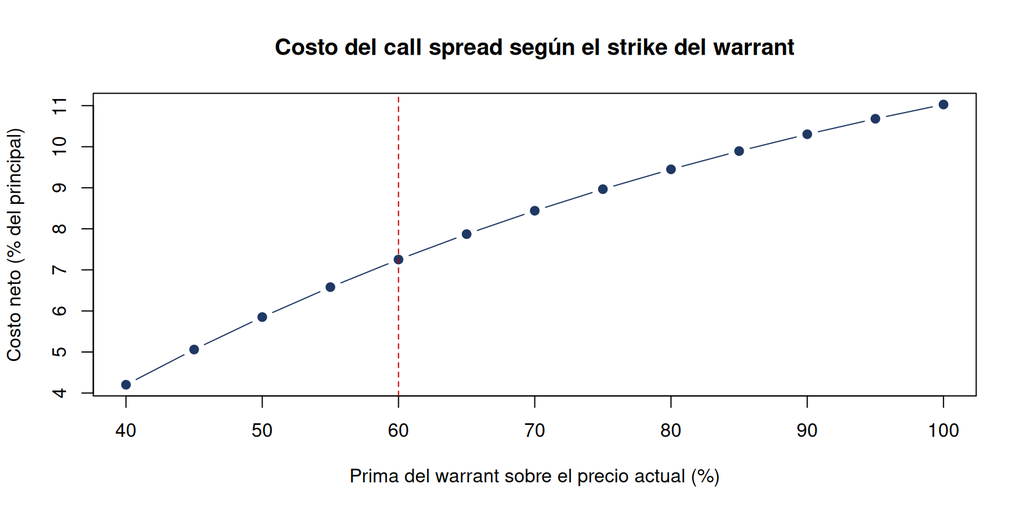

```r
primas_w <- seq(0.40, 1.00, by = 0.05)
costo_w  <- sapply(primas_w, function(pw) hedge - bs_call(precio, precio * (1 + pw), rf, s_w, Tm, q)["precio"] * acc_mm)
plot(primas_w * 100, costo_w / monto * 100, type = "b", pch = 19, col = azul, xlab = "Prima del warrant sobre el precio actual (%)",
     ylab = "Costo neto (% del principal)", main = "Costo del call spread según el strike del warrant")
abline(v = 60, lty = 2, col = rojo)
```

## Pago a vencimiento para WM

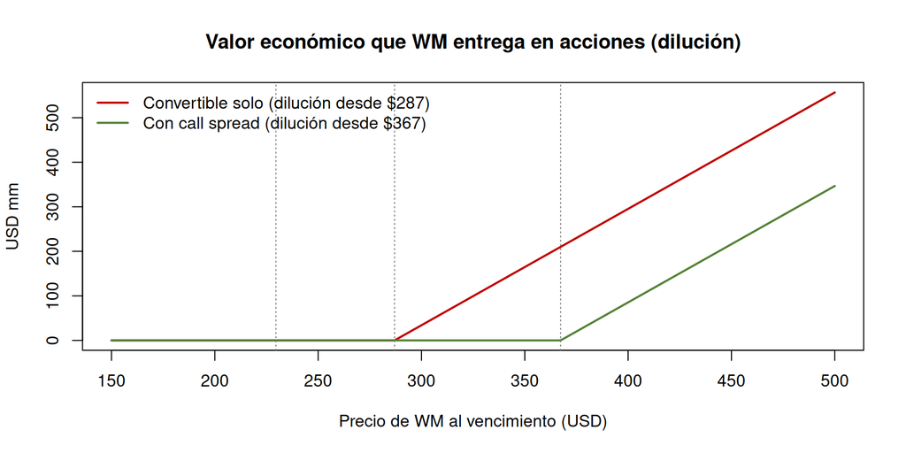

```r
ST <- seq(150, 500, by = 1)
sin_cs <- acc_mm * pmax(ST - K, 0)           # valor entregado por encima del principal (USD mm)
con_cs <- acc_mm * pmax(ST - Kw, 0)
plot(ST, sin_cs, type = "l", lwd = 2, col = rojo, xlab = "Precio de WM al vencimiento (USD)",
     ylab = "USD mm", main = "Valor económico que WM entrega en acciones (dilución)")
lines(ST, con_cs, lwd = 2, col = verde)
abline(v = c(precio, K, Kw), lty = 3, col = gris)
legend("topleft", c("Convertible solo (dilución desde $287)", "Con call spread (dilución desde $367)"),
       col = c(rojo, verde), lwd = 2, bty = "n")
```

```r
cat("\n\nDilución máxima por conversión:", round(acc_mm, 2), "mm de acciones =", pct(acc_mm / acciones, 2),
    "de las acciones en circulación\n")
```

Dilución máxima por conversión: 2.61 mm de acciones = 0.65% de las acciones en circulación

## Griegas de la posición

```r
gr_h <- callq[c("delta", "gamma", "vega")] * acc_mm
gr_w <- warr_c[c("delta", "gamma", "vega")] * acc_mm
tabla(data.frame(
  Griega = c("Delta (mm acciones)", "Gamma (mm acciones por USD)", "Vega (USD mm por punto de vol)"),
  Note_hedge_largo = round(gr_h, 4), Warrants_cortos = round(-gr_w, 4), Neto_WM = round(gr_h - gr_w, 4)),
  "Sensibilidades del call spread para WM (B-S-M)")
```

Sensibilidades del call spread para WM (B-S-M)

|  | Griega | Note_hedge_largo | Warrants_cortos | Neto_WM |
| --- | --- | --- | --- | --- |
| delta | Delta (mm acciones) | 1.4064 | -0.9355 | 0.4708 |
| gamma | Gamma (mm acciones por USD) | 0.0072 | -0.0077 | -0.0005 |
| vega | Vega (USD mm por punto de vol) | 5.1705 | -5.1308 | 0.0397 |

WM queda **larga en delta** (gana si sube la acción, lo que compensa la dilución entre $287 y $367) y casi **neutral en gamma y vega**: hoy las dos piernas tienen sensibilidades a la volatilidad muy parecidas, así que el costo del call spread depende sobre todo de *a qué volatilidad* se pacta cada pierna, no de movimientos posteriores de la volatilidad.

# 11. Sensibilidades

```r
primas <- c(0.15, 0.20, 0.25, 0.30, 0.35, 0.40)
vols   <- c(0.18, 0.2104, 0.227453, 0.25, 0.28)
grid <- sapply(primas, function(pr) sapply(vols, function(s) cupon_par_tf(prima = pr, s = s, N = 180)))
grid <- matrix(grid, nrow = length(vols))
dimnames(grid) <- list(paste0("Vol ", formatC(vols * 100, format = "f", digits = 1), "%"),
                       paste0("Prima ", primas * 100, "%"))
tabla(as.data.frame(round(grid * 100, 2)), "Cupón a la par (%) según prima de conversión y volatilidad (árbol T-F, 180 pasos)")
```

Cupón a la par (%) según prima de conversión y volatilidad (árbol T-F, 180 pasos)

|  | Prima 15% | Prima 20% | Prima 25% | Prima 30% | Prima 35% | Prima 40% |
| --- | --- | --- | --- | --- | --- | --- |
| Vol 18.0% | 2.26 | 2.70 | 3.10 | 3.44 | 3.71 | 3.97 |
| Vol 21.0% | 1.76 | 2.25 | 2.67 | 3.00 | 3.32 | 3.57 |
| Vol 22.7% | 1.49 | 1.99 | 2.40 | 2.77 | 3.07 | 3.35 |
| Vol 25.0% | 1.13 | 1.66 | 2.07 | 2.45 | 2.77 | 3.04 |
| Vol 28.0% | 0.65 | 1.17 | 1.64 | 2.01 | 2.37 | 2.65 |

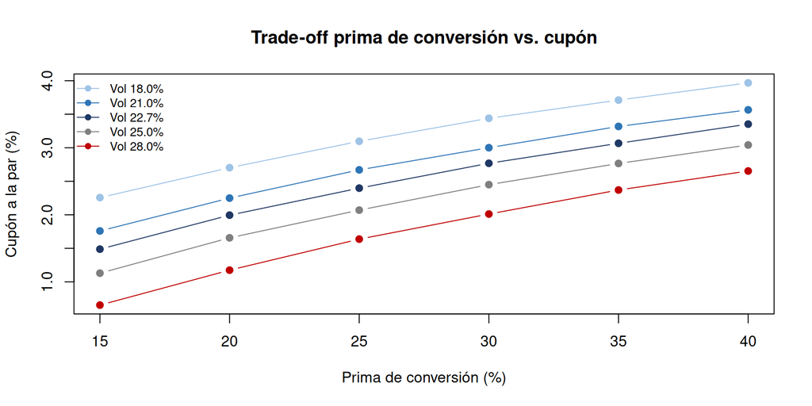

```r
matplot(primas * 100, t(grid) * 100, type = "b", pch = 19, lty = 1,
        col = c("#9DC3E6", azul2, azul, gris, rojo), xlab = "Prima de conversión (%)", ylab = "Cupón a la par (%)",
        main = "Trade-off prima de conversión vs. cupón")
legend("topleft", rownames(grid), col = c("#9DC3E6", azul2, azul, gris, rojo), lty = 1, pch = 19, bty = "n", cex = 0.8)
abline(h = y_wm * 100, lty = 2, col = gris); text(16, y_wm * 100, "Bono directo WM", pos = 1, cex = 0.7)
```

Más prima = menos dilución pero más cupón. Aun con prima de 40% y volatilidad baja, el cupón sigue muy por debajo del 5.65% de la deuda directa.

# 12. Comparación con pares

```r
archivo_pares <- "datos/pares.csv"
pares <- data.frame(Empresa = "Waste Management", Ticker = "WM", Calificacion_SP = "A-",
                    EV_EBITDA = 14.61, Deuda_EBITDA = 2.98, EBITDA_Intereses = 8.65,
                    Dividend_yield = 1.63, Beta_5a = 0.41)
if (file.exists(archivo_pares)) {
  ext <- read.csv(archivo_pares, stringsAsFactors = FALSE)
  ext <- ext[ext$Ticker != "WM" & rowSums(!is.na(ext[, -(1:3)])) > 0, ]
  if (nrow(ext) > 0) pares <- rbind(pares, ext[, names(pares)])
}
tabla(pares, "WM vs. pares (LSEG Workspace: Key Ratios LTM; pares consultados el 28-oct-2026, capturas 15a y 15b. Calificación, dividend yield y beta de los pares: consulta del equipo sin captura)")
```

WM vs. pares (LSEG Workspace: Key Ratios LTM; pares consultados el 28-oct-2026, capturas 15a y 15b. Calificación, dividend yield y beta de los pares: consulta del equipo sin captura)

| Empresa | Ticker | Calificacion_SP | EV_EBITDA | Deuda_EBITDA | EBITDA_Intereses | Dividend_yield | Beta_5a |
| --- | --- | --- | --- | --- | --- | --- | --- |
| Waste Management | WM | A- | 14.61 | 2.98 | 8.65 | 1.63 | 0.41 |
| Republic Services | RSG | A- | 15.67 | 2.58 | 9.23 | 1.14 | 0.35 |
| Waste Connections | WCN | BBB+ | 16.62 | 2.90 | 9.00 | 0.85 | 0.46 |

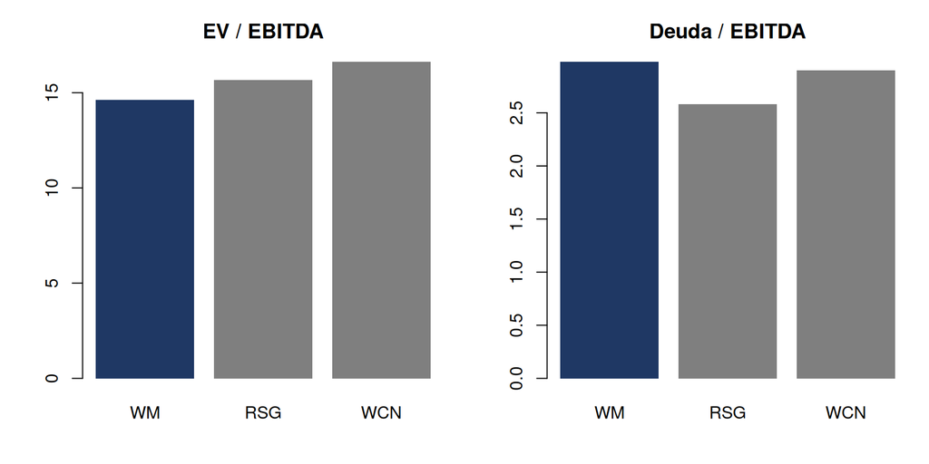

```r
if (nrow(pares) > 1) {
  par(mfrow = c(1, 2), mar = c(4, 4, 3, 1))
  barplot(pares$EV_EBITDA, names.arg = pares$Ticker, col = c(azul, rep(gris, nrow(pares) - 1)), border = NA, main = "EV / EBITDA")
  barplot(pares$Deuda_EBITDA, names.arg = pares$Ticker, col = c(azul, rep(gris, nrow(pares) - 1)), border = NA, main = "Deuda / EBITDA")
  par(mfrow = c(1, 1))
}
```

# 13. Impacto de la operación en WM

```r
straight <- monto * y_wm
tabla(data.frame(
  Concepto = c("Emisión del convertible", "(-) Comisión de colocación (supuesto 2%)", "(-) Recompra de bonos (tender)",
               "(-) Costo neto del call spread", "= Remanente de caja"),
  USD_mm = round(c(monto, -monto * comision, -tender, -neto_cs, remanente), 1)), "Fuentes y usos")
```

Fuentes y usos

| Concepto | USD_mm |
| --- | --- |
| Emisión del convertible | 750.0 |
| (-) Comisión de colocación (supuesto 2%) | -15.0 |
| (-) Recompra de bonos (tender) | -679.4 |
| (-) Costo neto del call spread | -54.4 |
| = Remanente de caja | 1.3 |

```r
tabla(data.frame(
  Concepto = c("Cupones anuales que se eliminan", "Cupón anual del convertible", "Ahorro anual antes de impuestos",
               "Ahorro anual después de impuestos (21%)", "Ahorro anual vs. emitir bono directo a 6 años",
               "Ahorro acumulado 6 años (sin descontar, antes de impuestos)"),
  USD_mm = round(c(cup_elim, cup_nuevo, ahorro, ahorro * (1 - tasa_imp), straight - cup_nuevo, ahorro * Tm), 1)),
  "Gasto por intereses")
```

Gasto por intereses

| Concepto | USD_mm |
| --- | --- |
| Cupones anuales que se eliminan | 44.2 |
| Cupón anual del convertible | 18.1 |
| Ahorro anual antes de impuestos | 26.2 |
| Ahorro anual después de impuestos (21%) | 20.7 |
| Ahorro anual vs. emitir bono directo a 6 años | 24.3 |
| Ahorro acumulado 6 años (sin descontar, antes de impuestos) | 157.0 |

```r
ebitda <- 114567 / 14.61; intereses <- ebitda / 8.65; deuda <- 23356
nueva_deuda <- deuda - sum(recompra$Nominal_mm) + monto
tabla(data.frame(
  Metrica = c("Deuda total (USD mm)", "Deuda / EBITDA", "EBITDA / Intereses", "Acciones potenciales por conversión (mm)"),
  Antes = c(usd(deuda), round(deuda / ebitda, 2), round(8.65, 2), "-"),
  Despues = c(usd(nueva_deuda), round(nueva_deuda / ebitda, 2), round(ebitda / (intereses - ahorro), 2),
              paste0(round(acc_mm, 2), " (", pct(acc_mm / acciones, 2), ")"))),
  "Métricas de crédito (EBITDA e intereses LTM implícitos en los ratios de LSEG)")
```

Métricas de crédito (EBITDA e intereses LTM implícitos en los ratios de LSEG)

| Metrica | Antes | Despues |
| --- | --- | --- |
| Deuda total (USD mm) | $23,356 | $23,459 |
| Deuda / EBITDA | 2.98 | 2.99 |
| EBITDA / Intereses | 8.65 | 8.91 |
| Acciones potenciales por conversión (mm) | - | 2.61 (0.65%) |

**Lectura:** la operación se autofinancia, pero con muy poco margen: sobran $1.3 mm, y ese remanente depende de dos supuestos (comisión de 2% y prima de tender de 1 punto); con una comisión de 2.2% ya sería negativo. La operación reduce el gasto por intereses en $26.2 mm al año y apenas mueve el apalancamiento (la deuda nominal sube $102.8 mm porque se recompra por encima de la par). La cobertura de intereses mejora a 8.9x.

**Ojo con el “ahorro”:** parte es contable. Los bonos viejos cotizan arriba de la par porque su cupón supera la tasa de mercado; al recomprarlos WM paga hoy ese exceso. Además, el cupón bajo existe porque WM le vende a los inversionistas una opción que vale $152.58 por bono. A valor justo la operación es cercana a VPN cero; el beneficio real es de **flujo de caja, perfil de vencimientos y costo de deuda reportado**, a cambio de una dilución que el call spread empuja hasta $367.33.

# 14. Alternativas: convertible vs. deuda directa vs. emisión de acciones

Se comparan tres formas de levantar los mismos USD 750 mm para el tender. Todas usan los insumos del motor (precio WM, YTM a 6 años de la curva de WM, dividend yield y el EBITDA LTM implícito en los ratios de LSEG).

```r
# Deuda directa: bono senior a 6 años al YTM de la curva de WM
cup_directo <- monto * y_wm
# Emisión de acciones: se colocan a precio de mercado (sin descuento de colocación, supuesto simplificador)
acc_nuevas  <- monto / precio                         # mm de acciones
div_extra   <- acc_nuevas * precio * q                # dividendos adicionales por año (USD mm)
deuda_eq    <- deuda - sum(recompra$Nominal_mm)       # la deuda baja: se recompra sin emitir deuda nueva
alt <- data.frame(
  Concepto = c("Costo anual en efectivo (USD mm)", "Ahorro anual vs. cupones eliminados (USD mm)",
               "Costo como % del monto", "Deuda / EBITDA después",
               "Acciones nuevas o potenciales (mm)", "Dilución sobre acciones actuales",
               "Cuándo ocurre la dilución", "Costo adicional al inicio (USD mm)"),
  Convertible_y_call_spread = c(round(cup_nuevo, 1), round(cup_elim - cup_nuevo, 1), pct(cupon_tf, 2),
               round(nueva_deuda / ebitda, 2), round(acc_mm, 2), pct(acc_mm / acciones, 2),
               paste0("Solo si WM supera ", usd(Kw, 0), " (call spread)"), round(neto_cs, 1)),
  Deuda_directa = c(round(cup_directo, 1), round(cup_elim - cup_directo, 1), pct(y_wm, 2),
               round(nueva_deuda / ebitda, 2), "0", "0%", "Nunca", "0"),
  Emision_acciones = c(round(div_extra, 1), round(cup_elim - div_extra, 1), pct(q, 2),
               formatC(deuda_eq / ebitda, format = "f", digits = 2), round(acc_nuevas, 2), pct(acc_nuevas / acciones, 2),
               "Inmediata", "0")
)
tabla(alt, "Comparación de alternativas para financiar el tender de USD 750 mm")
```

Comparación de alternativas para financiar el tender de USD 750 mm

| Concepto | Convertible_y_call_spread | Deuda_directa | Emision_acciones |
| --- | --- | --- | --- |
| Costo anual en efectivo (USD mm) | 18.1 | 42.4 | 12.2 |
| Ahorro anual vs. cupones eliminados (USD mm) | 26.2 | 1.9 | 32 |
| Costo como % del monto | 2.41% | 5.65% | 1.63% |
| Deuda / EBITDA después | 2.99 | 2.99 | 2.90 |
| Acciones nuevas o potenciales (mm) | 2.61 | 0 | 3.27 |
| Dilución sobre acciones actuales | 0.65% | 0% | 0.82% |
| Cuándo ocurre la dilución | Solo si WM supera $367 (call spread) | Nunca | Inmediata |
| Costo adicional al inicio (USD mm) | 54.4 | 0 | 0 |

**Lectura:**

- **Deuda directa** casi no ahorra: reemplazar cupones de $44.2 mm por $42.4 mm deja apenas $1.9 mm al año. No diluye, pero no resuelve el objetivo de bajar el costo.
- **Acciones** bajan el apalancamiento a 2.9x, pero diluyen 0.82% desde el primer día y el “costo” en dividendos (1.63%) es engañoso: el costo real del capital es el rendimiento que piden los accionistas, que es mayor que el de la deuda. Además, emitir acciones suele leerse como señal de que la acción está cara.
- **Convertible con call spread** tiene el menor costo en efectivo de las alternativas de deuda y solo diluye si la acción sube más de 60%. A cambio, WM paga hoy $54.4 mm por el call spread y vende a los inversionistas una opción (ver el *Ojo con el “ahorro”* de la sección 13).

# 15. Cobertura de tasa del tender: DV01, T-lock, swap y futuros

Mientras se anuncia y se fija el precio del tender, WM queda expuesta a las tasas: **si las tasas bajan, los bonos que va a recomprar suben de precio y el tender cuesta más.** Primero se mide esa exposición (DV01) y después el tamaño de la cobertura con tres instrumentos.

```r
# ---- 1. DV01 de la canasta del tender (precios ask LSEG 21-oct-2026, liquidación T+2) ----
liq <- as.Date("2026-10-23")
recompra$Vence <- as.Date(c("2028-07-15", "2032-05-15", "2039-11-30"))
d360 <- function(a, b) {   # días 30/360, convención de bonos corporativos de EE.UU.
  da <- min(as.numeric(format(a, "%d")), 30); db <- as.numeric(format(b, "%d")); if (da == 30) db <- min(db, 30)
  360 * (as.numeric(format(b, "%Y")) - as.numeric(format(a, "%Y"))) +
    30 * (as.numeric(format(b, "%m")) - as.numeric(format(a, "%m"))) + db - da
}
precio_sucio <- function(y, cup, vence, liq) {   # por 100 de nominal, cupón semestral
  fechas <- rev(seq(vence, by = "-6 months", length.out = 60))
  prox <- fechas[fechas > liq]; ult <- max(fechas[fechas <= liq])
  w <- (180 - d360(ult, liq)) / 180; k <- 0:(length(prox) - 1)
  cf <- rep(100 * cup / 2, length(prox)); cf[length(cf)] <- cf[length(cf)] + 100
  c(sucio = sum(cf / (1 + y / 2)^(k + w)), corrido = 100 * cup / 2 * d360(ult, liq) / 180)
}
# YTM implícito en el precio ask (limpio) y duración modificada numérica
recompra$YTM <- mapply(function(cup, v, pa) uniroot(function(y) {
  p <- precio_sucio(y, cup, v, liq); p[1] - p[2] - pa }, c(0, 0.2), tol = 1e-12)$root,
  recompra$Cupon, recompra$Vence, recompra$Precio_ask)
recompra$Sucio <- mapply(function(y, cup, v) precio_sucio(y, cup, v, liq)[1], recompra$YTM, recompra$Cupon, recompra$Vence)
recompra$Dmod <- mapply(function(y, cup, v) { h <- 1e-4
  (precio_sucio(y - h, cup, v, liq)[1] - precio_sucio(y + h, cup, v, liq)[1]) / (2 * h * precio_sucio(y, cup, v, liq)[1]) },
  recompra$YTM, recompra$Cupon, recompra$Vence)
recompra$DV01 <- recompra$Nominal_mm * 1e6 * recompra$Sucio / 100 * recompra$Dmod * 1e-4   # USD por pb
dv01_total <- sum(recompra$DV01)
tabla(data.frame(row.names = NULL, Bono = recompra$Bono, YTM = pct(recompra$YTM, 3), Precio_sucio = round(recompra$Sucio, 3),
                 Duracion_mod = round(recompra$Dmod, 2), DV01_USD_por_pb = usd(recompra$DV01)),
      "DV01 de los bonos a recomprar")
```

DV01 de los bonos a recomprar

| Bono | YTM | Precio_sucio | Duracion_mod | DV01_USD_por_pb |
| --- | --- | --- | --- | --- |
| WM 7.00% 15-jul-2028 | 5.252% | 104.746 | 1.59 | $42,918 |
| WM 7.75% 15-may-2032 | 5.863% | 112.239 | 4.40 | $70,897 |
| WM 6.125% 30-nov-2039 | 5.870% | 104.733 | 8.77 | $225,748 |

```r
tabla(data.frame(row.names = NULL, Baja_de_tasas_pb = c(10, 25, 50, 100),
                 Aumento_costo_tender_USD_mm = round(dv01_total * c(10, 25, 50, 100) / 1e6, 2)),
      "Sensibilidad del costo del tender (aproximación lineal con DV01)")
```

Sensibilidad del costo del tender (aproximación lineal con DV01)

| Baja_de_tasas_pb | Aumento_costo_tender_USD_mm |
| --- | --- |
| 10 | 3.40 |
| 25 | 8.49 |
| 50 | 16.98 |
| 100 | 33.96 |

```r
# ---- 2. Tamaño de la cobertura (Treasuries benchmark, LSEG Rates View 03-nov-2026) ----
ust_b <- c("2Y" = 0.04629, "5Y" = 0.04757, "7Y" = 0.04848, "10Y" = 0.04964)
plazo <- c("2Y" = 2, "5Y" = 5, "7Y" = 7, "10Y" = 10)
dv01_par <- function(y, T) {   # DV01 de USD 1 mm de un bono a la par (USD por pb)
  t <- 1:(2 * T); cf <- rep(100 * y / 2, 2 * T); cf[2 * T] <- cf[2 * T] + 100
  p <- function(yy) sum(cf / (1 + yy / 2)^t); (p(y - 1e-4) - p(y + 1e-4)) / 2 / 100 * 1e6
}
dvp <- mapply(dv01_par, ust_b, plazo)
nodo <- c("2Y", "5Y", "10Y")             # 2028 -> 2 años, 2032 -> 5 años, 2039 -> 10 años
tlock <- recompra$DV01 / dvp[nodo]       # nocional en USD mm por nodo
tabla(data.frame(row.names = NULL, Bono = recompra$Bono, Nodo_Treasury = nodo, Yield_benchmark = pct(ust_b[nodo], 3),
                 DV01_por_USD_1mm = round(dvp[nodo], 1), Nocional_T_lock_USD_mm = round(tlock, 1)),
      paste0("T-lock por nodos: nocional total USD ", round(sum(tlock), 1), " mm"))
```

T-lock por nodos: nocional total USD 677.3 mm

| Bono | Nodo_Treasury | Yield_benchmark | DV01_por_USD_1mm | Nocional_T_lock_USD_mm |
| --- | --- | --- | --- | --- |
| WM 7.00% 15-jul-2028 | 2Y | 4.629% | 188.9 | 227.1 |
| WM 7.75% 15-may-2032 | 5Y | 4.757% | 440.4 | 161.0 |
| WM 6.125% 30-nov-2039 | 10Y | 4.964% | 780.8 | 289.1 |

```r
tabla(data.frame(row.names = NULL, Alternativa = paste("Un solo T-lock a", names(dvp[-1])),
                 Nocional_USD_mm = round(dv01_total / dvp[-1], 1)),
      "Alternativa con un solo plazo (más simple, con riesgo de curva)")
```

Alternativa con un solo plazo (más simple, con riesgo de curva)

| Alternativa | Nocional_USD_mm |
| --- | --- |
| Un solo T-lock a 5Y | 771.1 |
| Un solo T-lock a 7Y | 577.8 |
| Un solo T-lock a 10Y | 434.9 |

```r
# ---- 3. Futuros del Tesoro (CME, precios y CTD de LSEG Rates View 03-nov-2026) ----
# DV01 del futuro ~ DV01 del CTD / factor de conversión. El factor se aproxima con la regla de CME
# (rendimiento de 6% y vencimiento redondeado al trimestre): es una APROXIMACIÓN.
fut <- data.frame(Futuro = c("TUZ6 (2 años)", "FVZ6 (5 años)", "TNZ6 (Ultra 10 años)"),
                  Cubre = recompra$Bono, Nominal = c(2e5, 1e5, 1e5),
                  CTD = c("T 4.750% sep-2028", "T 3.500% feb-2031", "T 4.375% may-2036"),
                  CTD_cupon = c(0.0475, 0.035, 0.04375), CTD_vence = as.Date(c("2028-09-30", "2031-02-28", "2036-05-15")),
                  CTD_yield = c(0.04635, 0.04744, 0.04959))
vida <- as.numeric(fut$CTD_vence - as.Date("2026-12-01")) / 365.25
fc <- function(cup, T) { Tq <- floor(T * 4) / 4; n <- floor(Tq * 2); fr <- Tq * 2 - n
  t <- (1:n) + fr; cf <- rep(cup / 2, n); cf[n] <- cf[n] + 1
  sum(cf / 1.03^t) + (if (fr > 0) cup / 2 * fr else 0) }
dv01_ctd <- function(y, cup, T) { n <- round(T * 2); t <- 1:n; cf <- rep(cup / 2 * 100, n); cf[n] <- cf[n] + 100
  p <- function(yy) sum(cf / (1 + yy / 2)^t); (p(y - 1e-4) - p(y + 1e-4)) / 2 / 100 }
fut$FC <- mapply(fc, fut$CTD_cupon, vida)
fut$DV01_contrato <- mapply(dv01_ctd, fut$CTD_yield, fut$CTD_cupon, vida) * fut$Nominal / fut$FC
fut$Contratos <- recompra$DV01 / fut$DV01_contrato
tabla(data.frame(row.names = NULL, Futuro = fut$Futuro, Cubre = fut$Cubre, CTD = fut$CTD, Factor_conv_aprox = round(fut$FC, 4),
                 DV01_por_contrato_USD = round(fut$DV01_contrato, 1), Contratos_largos = round(fut$Contratos)),
      "Cobertura con futuros (cantidades aproximadas)")
```

Cobertura con futuros (cantidades aproximadas)

| Futuro | Cubre | CTD | Factor_conv_aprox | DV01_por_contrato_USD | Contratos_largos |
| --- | --- | --- | --- | --- | --- |
| TUZ6 (2 años) | WM 7.00% 15-jul-2028 | T 4.750% sep-2028 | 0.9798 | 38.6 | 1,111 |
| FVZ6 (5 años) | WM 7.75% 15-may-2032 | T 3.500% feb-2031 | 0.9123 | 38.5 | 1,843 |
| TNZ6 (Ultra 10 años) | WM 6.125% 30-nov-2039 | T 4.375% may-2036 | 0.8862 | 82.4 | 2,738 |

```r
# ---- 4. Swap de tasa (receive fixed). Swap spreads de LSEG Rates View 03-nov-2026 ----
swap_sp <- c("2Y" = -14.50, "5Y" = -28.38, "7Y" = -34.88, "10Y" = -39.38) / 1e4
swap_r  <- ust_b + swap_sp
dvs <- mapply(dv01_par, swap_r, plazo)
tabla(data.frame(row.names = NULL, Plazo = names(ust_b), Treasury = pct(ust_b, 3), Swap_spread_pb = round(swap_sp * 1e4, 2),
                 Tasa_swap = pct(swap_r, 3), Nocional_receive_fixed_USD_mm = c(round(recompra$DV01[1] / dvs["2Y"], 1),
                 round(recompra$DV01[2] / dvs["5Y"], 1), "-", round(recompra$DV01[3] / dvs["10Y"], 1))),
      "Cobertura con swaps de tasa (WM recibe fijo)")
```

Cobertura con swaps de tasa (WM recibe fijo)

| Plazo | Treasury | Swap_spread_pb | Tasa_swap | Nocional_receive_fixed_USD_mm |
| --- | --- | --- | --- | --- |
| 2Y | 4.629% | -14.50 | 4.484% | 226.7 |
| 5Y | 4.757% | -28.38 | 4.473% | 159.8 |
| 7Y | 4.848% | -34.88 | 4.499% | - |
| 10Y | 4.964% | -39.38 | 4.570% | 283.8 |

**Cómo leerlo.** La canasta del tender tiene un DV01 de **$339,562 por punto base**: una baja de 25 pb en tasas encarece la recompra en $8.5 mm, varias veces el remanente de caja de $1.3 mm (sección 13). Sin cobertura, una baja de solo 4 pb haría que la operación dejara de autofinanciarse.

**Recomendación de cobertura:**

1. **Dirección:** WM debe ganar si las tasas **bajan** (largo en Treasuries, receive fixed). Es la posición contraria a la del T-lock típico de un emisor, que se protege de que las tasas suban. En el caso Molson Coors el T-lock generó una ganancia de USD 1.4 mm.
2. **Instrumento preferido: T-lock por nodos** (≈ USD 677 mm en 2, 5 y 10 años). Si el tender se fija como *spread fijo sobre un Treasury de referencia* (práctica usual), el precio depende directamente de ese Treasury, y el T-lock cubre casi exactamente ese riesgo. Se liquida en efectivo el día del *pricing*.
3. **Futuros** (TU, FV y Ultra 10): son líquidos y no tienen riesgo de contraparte, pero requieren margen diario y los contratos son aproximados (factor de conversión estimado y riesgo de cambio de CTD).
4. **Swaps:** los swap spreads son negativos y distintos por plazo (de -14.5 a -39.4 pb). La cobertura con swaps deja **riesgo de base** (swap spread) frente a un tender que se fija contra Treasuries, por lo que es la opción menos precisa para este caso.
5. **Límite:** la cobertura se cierra cuando se fija el precio del tender. Los DV01 son una aproximación lineal; para movimientos de más de 50 pb la convexidad hace que el aumento real del costo sea algo mayor.

# 16. Swaps de cobertura (Hull, cap. 7)

El cuaderno de clase de swaps (Hull, cap. 7) se replicó con los datos de WM en `notebooks/WM_Swaps_Hull_cap7.ipynb`. Aquí se reproducen sus cálculos principales. **Todos los swaps se plantean desde la tesorería de WM y con fines de cobertura:**

| Swap | Posición de WM | Riesgo que cubre |
| --- | --- | --- |
| Tasa del tender | Recibe fijo / paga SOFR | Que bajen las tasas antes del *pricing* y se encarezca la recompra (sección 15) |
| Deuda variable | Paga fijo / recibe SOFR | Alzas de tasa sobre USD 2.9 mil mm de deuda variable (10-K, Item 7A) |
| Divisas CAD/USD | Recibe CAD / paga USD | Tipo de cambio del bono WM 3.944% 2033 en CAD (C$ 700 mm) |
| Equity swap | Recibe el rendimiento de WM / paga fijo | Dilución económica de los warrants vendidos en el call spread (sección 10) |

## Swap de tasa del tender

```r
# ---- Curva swap: Treasuries + swap spreads (LSEG Rates View 03-nov-2026, sección 15) y bootstrapping ----
dt_s  <- 0.5
t_s   <- seq(dt_s, 10, by = dt_s)                                # semestres hasta 10 años
par_t <- approx(plazo, swap_r, xout = t_s, rule = 2)$y          # tasa par por semestre (plana debajo de 2 años)
D <- numeric(length(par_t))
for (i in seq_along(par_t)) D[i] <- (1 - par_t[i] * dt_s * sum(D[seq_len(i - 1)])) / (1 + par_t[i] * dt_s)
z_s <- -log(D) / t_s                                             # tasas cero continuas

# Valor para WM (recibe fijo) ante un desplazamiento paralelo: enfoque de bonos y enfoque de FRAs (Hull 7.7)
valuar_swap <- function(shift_pb, noc, n) {
  K  <- (1 - D[n]) / (dt_s * sum(D[1:n]))                        # tasa par del swap al inicio
  Zs <- exp(-(z_s[1:n] + shift_pb / 1e4) * t_s[1:n])
  B_fijo <- sum(noc * K * dt_s * Zs) + noc * Zs[n]
  f  <- (c(1, Zs[-n]) / Zs - 1) / dt_s                           # forwards semestrales
  c(bonos = B_fijo - noc, fras = sum(noc * dt_s * (K - f) * Zs), K = K)
}

# Nocionales receive fixed por nodo (mismos de la sección 15) y swap del nodo 5Y
noc_nodo <- c("2Y" = recompra$DV01[1] / dvs[["2Y"]], "5Y" = recompra$DV01[2] / dvs[["5Y"]],
              "10Y" = recompra$DV01[3] / dvs[["10Y"]]) * 1e6
n_nodo <- c("2Y" = 4, "5Y" = 10, "10Y" = 20)
N5 <- noc_nodo[["5Y"]]; Z5 <- D[1:10]
K5 <- (1 - Z5[10]) / (dt_s * sum(Z5))
f5 <- (c(1, Z5[-10]) / Z5 - 1) / dt_s
flujos5 <- data.frame(Semestre = 1:10, Forward = pct(f5, 3), Cobro_fijo_WM = usd(N5 * K5 * dt_s),
                      Pago_variable_WM = usd(N5 * f5 * dt_s), Neto_WM = usd(N5 * (K5 - f5) * dt_s))
tabla(flujos5, paste0("Swap 5Y: WM recibe ", pct(K5, 3), " fijo sobre USD ", round(N5 / 1e6, 1),
                      " mm y paga SOFR (flujos variables proyectados con las forwards)"))
```

Swap 5Y: WM recibe 4.473% fijo sobre USD 159.8 mm y paga SOFR (flujos variables proyectados con las forwards)

[output not shown]

```r
v25 <- valuar_swap(-25, N5, 10)
tabla(data.frame(Enfoque = c("Bonos (B_fijo - B_variable)", "FRAs (suma de forwards)"),
                 Valor_para_WM_tras_baja_25pb = usd(c(v25[["bonos"]], v25[["fras"]]))),
      "Valuación del swap 5Y después de una baja paralela de 25 pb: ambos enfoques coinciden")
```

Valuación del swap 5Y después de una baja paralela de 25 pb: ambos enfoques coinciden

| Enfoque | Valor_para_WM_tras_baja_25pb |
| --- | --- |
| Bonos (B_fijo - B_variable) | $1,823,041 |
| FRAs (suma de forwards) | $1,823,041 |

```r
dv01_sw <- sapply(names(n_nodo), function(k)
  (valuar_swap(-1, noc_nodo[[k]], n_nodo[[k]])[["bonos"]] - valuar_swap(1, noc_nodo[[k]], n_nodo[[k]])[["bonos"]]) / 2)
tabla(data.frame(Nodo = names(n_nodo), Nocional_USD_mm = round(noc_nodo / 1e6, 1),
                 Tasa_fija = pct(sapply(names(n_nodo), function(k) valuar_swap(0, 1, n_nodo[[k]])[["K"]]), 3),
                 DV01_swap_USD_pb = usd(dv01_sw)),
      paste0("DV01 de los tres swaps: ", usd(sum(dv01_sw)), " por pb vs. DV01 del tender ", usd(dv01_total)))
```

DV01 de los tres swaps: $347,135 por pb vs. DV01 del tender $339,562

|  | Nodo | Nocional_USD_mm | Tasa_fija | DV01_swap_USD_pb |
| --- | --- | --- | --- | --- |
| 2Y | 2Y | 226.7 | 4.484% | $43,880 |
| 5Y | 5Y | 159.8 | 4.473% | $72,483 |
| 10Y | 10Y | 283.8 | 4.570% | $230,772 |

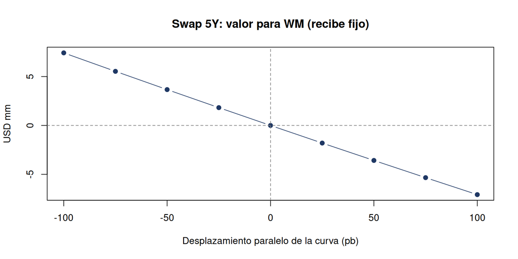

```r
desp <- seq(-100, 100, by = 25)
plot(desp, sapply(desp, function(s) valuar_swap(s, N5, 10)[["bonos"]]) / 1e6, type = "b", pch = 19, col = azul,
     xlab = "Desplazamiento paralelo de la curva (pb)", ylab = "USD mm", main = "Swap 5Y: valor para WM (recibe fijo)")
abline(h = 0, v = 0, col = gris, lty = 2)
```

## Deuda variable

WM tiene USD 2.9 mil mm de deuda expuesta a tasa variable (10-K 2025, Item 7A). Para cubrirse de alzas quiere **pagar fijo**. Como en el ejemplo de ventaja comparativa de Hull, la contraparte es un emisor AA que prefiere variable; WM pide prestado variable y con el swap queda en fijo. Tasas fijas de LSEG: WM 5.649% (curva a 6 años) y, como referencia AA, el bono **Apple 4.500% 12-may-2032** (YTM 4.905%, 27 pb sobre el Treasury; captura 12g). **Los márgenes sobre SOFR son supuestos.**

```r
fija_AA <- 0.04905; var_AA <- 0.0045         # AA: Apple 4.500% 12-may-2032, YTM 4.905% (LSEG REPS 05-nov-2026); SOFR+0.45% supuesto
fija_WM <- y_wm;   var_WM <- 0.0080          # WM: YTM a 6 años (LSEG); SOFR + 0.80% supuesto
ganancia <- (fija_WM - fija_AA) - (var_WM - var_AA); g <- ganancia / 2
X <- fija_AA - var_AA + g                    # fija que WM paga a AA; AA paga SOFR a WM
costo_WM <- var_WM + X; costo_AA <- var_AA - g
deuda_var <- 2900                            # USD mm
tabla(data.frame(Concepto = c("Diferencia en tasa fija", "Diferencia en tasa variable", "Ganancia total (cada uno la mitad)",
                              "Tasa fija que WM paga en el swap", "Costo final de WM (fijo)", "WM emitiendo fijo directo",
                              "Costo final de la contraparte AA", "Gasto extra de WM por +100 pb sin cobertura"),
                 Valor = c(pct(fija_WM - fija_AA), pct(var_WM - var_AA), pct(ganancia), pct(X, 3), pct(costo_WM, 3),
                           pct(fija_WM, 3), paste0("SOFR + ", pct(costo_AA)), paste(usd(deuda_var * 0.01, 1), "mm al año"))),
      "Ventaja comparativa: WM paga fijo / recibe SOFR")
```

Ventaja comparativa: WM paga fijo / recibe SOFR

| Concepto | Valor |
| --- | --- |
| Diferencia en tasa fija | 0.74% |
| Diferencia en tasa variable | 0.35% |
| Ganancia total (cada uno la mitad) | 0.39% |
| Tasa fija que WM paga en el swap | 4.652% |
| Costo final de WM (fijo) | 5.452% |
| WM emitiendo fijo directo | 5.649% |
| Costo final de la contraparte AA | SOFR + 0.25% |
| Gasto extra de WM por +100 pb sin cobertura | $29.0 mm al año |

Con el swap, un alza de 100 pb ya no aumenta el gasto financiero de WM (sin cobertura serían $29 mm al año; el 10-K estima USD 35 mm). Como advierte Hull, parte de la “ganancia” refleja que el margen variable se puede revisar y un intermediario cobraría 3-4 pb.

## Divisas CAD/USD

El bono de WM en dólares canadienses es el **WM 3.944% 15-jul-2033 (CA94107TAB76), C$ 700 mm**, con cupón semestral (LSEG Workspace, 06-nov-2026; YTM 4.186%, 78 pb sobre la curva de Canadá). WM entra a un swap fijo-fijo en el que **recibe 3.944% en CAD** (con lo que paga el bono) y **paga una tasa fija en USD**. La tasa USD se fija para que el swap valga cero al inicio. Como simplificación, el primer cupón se toma completo.

```r
# ---- Datos LSEG Workspace, 06-nov-2026 ----
S0_cad  <- 1.4124                  # USD/CAD spot (CAD por USD), CAD= 15:22 (bid 1.4122 / ask 1.4126)
N_cad   <- 700e6; cup_cad <- 0.03944
r_cad   <- 0.0340                  # curva del Gobierno de Canadá interpolada a 6.69 años (REPS/EJV)
f_cad   <- seq(as.Date("2027-01-15"), as.Date("2033-07-15"), by = "6 months")
tt      <- as.numeric(f_cad - as.Date("2026-11-06")) / 365
T_cad   <- max(tt); N_usd <- N_cad / S0_cad
r_usd   <- approx(plazo, swap_r, xout = T_cad)$y                     # curva swap USD interpolada
cf_cad  <- rep(N_cad * cup_cad / 2, length(tt)); cf_cad[length(tt)] <- cf_cad[length(tt)] + N_cad
B_cad   <- sum(cf_cad * exp(-r_cad * tt))
K_usd   <- (B_cad / S0_cad / N_usd - exp(-r_usd * T_cad)) / sum(0.5 * exp(-r_usd * tt))
cf_usd  <- rep(N_usd * K_usd / 2, length(tt)); cf_usd[length(tt)] <- cf_usd[length(tt)] + N_usd
valor_cad <- function(S) B_cad / S - sum(cf_usd * exp(-r_usd * tt))   # WM recibe CAD y paga USD (Hull 7.10)
esc <- S0_cad * c(0.90, 0.95, 1, 1.05, 1.10)
tabla(data.frame(CAD_por_USD = round(esc, 4), Movimiento_CAD = c("se aprecia 10%", "se aprecia 5%", "sin cambio", "se deprecia 5%", "se deprecia 10%"),
                 Valor_swap_para_WM_USD_mm = round(sapply(esc, valor_cad) / 1e6, 1),
                 Cambio_principal_CAD_en_USD_mm = round((N_cad / esc - N_usd) / 1e6, 1)),
      paste0("Swap fijo-fijo: WM recibe ", pct(cup_cad, 3), " en CAD y paga ", pct(K_usd, 3),
             " en USD sobre USD ", round(N_usd / 1e6, 1), " mm (", length(tt), " pagos semestrales hasta jul-2033)"))
```

Swap fijo-fijo: WM recibe 3.944% en CAD y paga 5.023% en USD sobre USD 495.6 mm (14 pagos semestrales hasta jul-2033)

| CAD_por_USD | Movimiento_CAD | Valor_swap_para_WM_USD_mm | Cambio_principal_CAD_en_USD_mm |
| --- | --- | --- | --- |
| 1.2712 | se aprecia 10% | 57.4 | 55.1 |
| 1.3418 | se aprecia 5% | 27.2 | 26.1 |
| 1.4124 | sin cambio | 0.0 | 0.0 |
| 1.4830 | se deprecia 5% | -24.6 | -23.6 |
| 1.5536 | se deprecia 10% | -47.0 | -45.1 |

Cuando el CAD se aprecia, el bono en CAD le cuesta más a WM en dólares, pero el swap gana casi lo mismo: la deuda queda **sintéticamente en USD** a 5.023%. Las diferencias entre las dos últimas columnas vienen de los cupones y del descuento.

## Equity swap (warrants)

En el call spread WM **vende warrants** al 60% de prima. Si la acción sube mucho, se ejercen y diluyen. Con un equity swap en el que WM **recibe el rendimiento de su acción y paga fijo** (tasa swap a 2 años), el swap paga cuando los warrants se encarecen. Nocional = delta de los warrants × acciones subyacentes × precio. Ilustración retrospectiva con el último año de precios: como si los warrants se hubieran vendido hace un año.

```r
p1 <- tail(px, 253); pos_q <- round(seq(1, nrow(p1), length.out = 5))
S_ini <- p1$Cierre[pos_q[1]]; K_wr <- 1.60 * S_ini; acc_w <- acc_mm * 1e6
delta_w <- bs_call(S_ini, K_wr, rf, s_w, Tm, q)[["delta"]]
N_eq <- delta_w * acc_w * S_ini; fijo_eq <- swap_r[["2Y"]]
eq <- t(sapply(1:4, function(i) {
  Sa <- p1$Cierre[pos_q[i]]; Sb <- p1$Cierre[pos_q[i + 1]]
  dW <- acc_w * (bs_call(Sb, K_wr, rf, s_w, Tm - 0.25 * i, q)[["precio"]] - bs_call(Sa, K_wr, rf, s_w, Tm - 0.25 * (i - 1), q)[["precio"]])
  sw <- N_eq * (Sb / Sa - 1) - N_eq * fijo_eq / 4
  c(rend = Sb / Sa - 1, dW = dW, sw = sw)
}))
tabla(data.frame(Trimestre = paste0("T", 1:4, " (al ", format(p1$Fecha[pos_q[-1]], "%d-%b-%Y"), ")"),
                 Rend_WM = pct(eq[, "rend"]), Costo_warrants_USD_mm = round(eq[, "dW"] / 1e6, 2),
                 Flujo_swap_WM_USD_mm = round(eq[, "sw"] / 1e6, 2), Resultado_cubierto_USD_mm = round((eq[, "sw"] - eq[, "dW"]) / 1e6, 2)),
      paste0("Delta de los warrants ", round(delta_w, 3), " → nocional del swap USD ", round(N_eq / 1e6, 1), " mm"))
```

Delta de los warrants 0.358 → nocional del swap USD 183.8 mm

| Trimestre | Rend_WM | Costo_warrants_USD_mm | Flujo_swap_WM_USD_mm | Resultado_cubierto_USD_mm |
| --- | --- | --- | --- | --- |
| T1 (al 03-Feb-2026) | 13.11% | 23.56 | 22.04 | -1.52 |
| T2 (al 05-May-2026) | 0.13% | -3.19 | -1.82 | 1.37 |
| T3 (al 05-Aug-2026) | 0.35% | -2.72 | -1.41 | 1.30 |
| T4 (al 03-Nov-2026) | 5.61% | 10.49 | 8.26 | -2.23 |

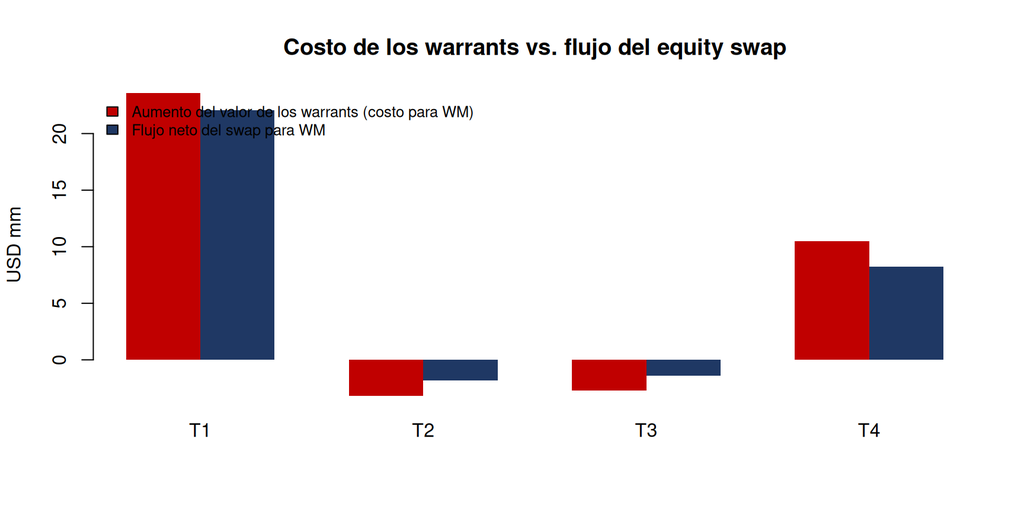

```r
barplot(rbind(eq[, "dW"], eq[, "sw"]) / 1e6, beside = TRUE, names.arg = paste0("T", 1:4), col = c(rojo, azul), border = NA,
        ylab = "USD mm", main = "Costo de los warrants vs. flujo del equity swap")
legend("topleft", c("Aumento del valor de los warrants (costo para WM)", "Flujo neto del swap para WM"),
       fill = c(rojo, azul), bty = "n", cex = 0.8)
```

El swap se mueve en la misma dirección que el costo de los warrants, así que el resultado cubierto varía mucho menos. Lo que queda viene de la gamma de los warrants (el delta cambia con el precio) y de la pierna fija, que es el costo de la cobertura.

## Réplica propuesta en Alpaca

Alpaca no opera swaps OTC. Diseñamos la réplica de cada cobertura con instrumentos listados (cuenta *paper*, USD 10 mil por pierna; código en las secciones 6 y 7 del notebook):

| Swap | Réplica |
| --- | --- |
| Tasa del tender (recibe fijo / paga variable) | Compra de IEF (Treasuries 7-10 años) + venta en corto de BIL (T-bills ≈ tasa variable) |
| Divisas (recibe CAD / paga USD) | Compra de FXC (dólar canadiense) |
| Equity swap (recibe WM / paga fijo) | Compra de WM, financiada con la caja de la cuenta |

**Estado:** las órdenes de la cuenta *paper* se enviaron como órdenes **limitadas y no se ejecutaron**, por lo que no hay posiciones ni P&L realizado que reportar. La réplica queda como diseño: en un swap OTC real no hay que fondear ninguna pierna, mientras que la réplica con ETFs tiene costo de financiamiento, costo de préstamo de los cortos y diferencias por acciones enteras.

# 17. Riesgos

[output not shown]

# 18. Recomendación

**Recomendamos que WM emita el convertible de USD 750 mm a 6 años con cupón alrededor de 2.41% y prima de conversión de 25%, combinado con un call spread que eleve la prima efectiva a 60%.**

1. **Costo:** se financia 324 pb por debajo de su deuda directa y reduce el gasto por intereses en $26.2 mm al año ($20.7 mm después de impuestos).
2. **Autofinanciable, con poco margen:** los USD 750 mm cubren el tender, la comisión y el call spread ($54.4 mm, 7.3% del principal, muy parecido al 8.6% de Molson).
3. **Crédito:** el apalancamiento queda en 2.99x y la cobertura mejora, por lo que no se espera presión sobre la calificación A- (es una inferencia, no una opinión de las agencias).
4. **Condiciones:** (i) no bajar la prima de conversión de 25%: con prima de 20% el ahorro sube poco y la dilución llega antes; (ii) negociar la volatilidad a la que el banco compra los warrants: cada punto de volatilidad del warrant cambia el costo neto en ~$5.1 mm.
5. **Cubrir la tasa del tender:** el DV01 de la canasta es $339,562 por pb; recomendamos un T-lock por nodos (≈ USD 677 mm) desde el anuncio hasta el *pricing* del tender (sección 15).
6. **Coberturas complementarias con swaps (sección 16):** pagar fijo sobre la deuda variable, convertir el bono en CAD a USD con un swap de divisas y, si la dilución es una preocupación, cubrir los warrants con un equity swap en el que WM recibe el rendimiento de su acción.

# 19. Parte operativa: call spread en Alpaca (paper trading)

Para replicar el call spread con opciones listadas se envió desde Colab (`notebooks/WM_Volatilidad_GARCH_y_Operacion_Alpaca.ipynb`) una orden multi-pierna en la cuenta **paper** (dinero simulado) de Alpaca el 03-nov-2026:

- **Compra** de 1 call WM 19-ene-2029 strike 290 (*buy to open*), equivalente al *note hedge* (precio de conversión ≈ USD 287).
- **Venta** de 1 call WM 19-ene-2029 strike 340 (*sell to open*), equivalente al *warrant*.
- Orden limitada con débito neto de USD 9.07 por acción (USD 907 por contrato), vigencia de un día.

**Estado:** la orden limitada de un día **no se ejecutó** (quedó en estado “new” y expiró sin llenarse), por lo que no se reporta ninguna posición ni resultado realizado. El strike corto disponible (340) queda por debajo del strike del warrant del modelo (USD 367.33), así que la réplica es aproximada y a escala de 1 contrato.

# Anexo A. Capturas de pantalla (LSEG, Colab y Alpaca)

Las capturas de LSEG Workspace se tomaron el **03-nov-2026**; los valores del análisis son del 21-oct-2026 (pares: 28-oct-2026), por lo que algunos números de las pantallas difieren.

**LSEG Overview: descripción, estructura de capital y Key Ratios (03-nov-2026; LTM al 30-sep-26)**

[figure not shown]

**LSEG Overview: Price Performance, enterprise value y ratios (03-nov-2026)**

[figure not shown]

**LSEG Financial Summary (FA) en USD: ingresos, activos, deuda y capital, FY2021-2025 (03-nov-2026)**

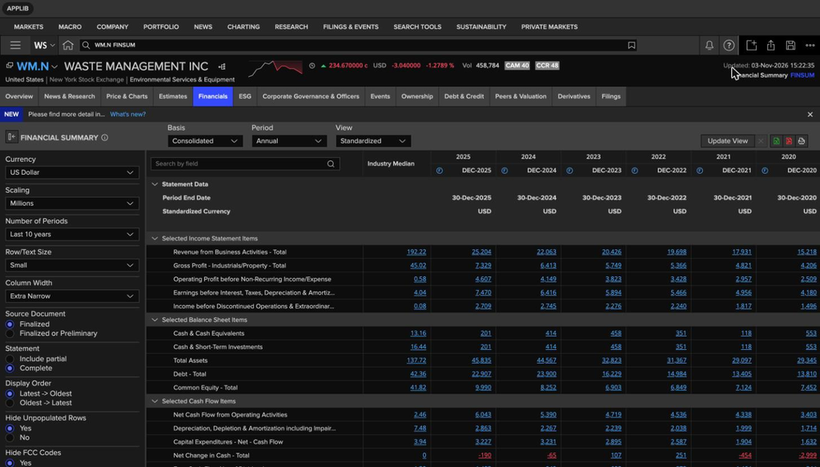

**LSEG Debt Structure (DS): bonos vigentes por moneda (03-nov-2026)**

[figure not shown]

**LSEG Issuer Curve 0#WMUSDABMK=: yield, spreads y probabilidad de default (03-nov-2026)**

[figure not shown]

**LSEG Issuer Curve: bonos constituyentes, incluye 7.00% 2028, 7.75% 2032 y 6.125% 2039 (03-nov-2026)**

[figure not shown]

**LSEG Issuer Ratings: S&P, Moody’s, Fitch y otras agencias (03-nov-2026)**

[figure not shown]